# tfm__dionisio_gonzalez_memoria_final

[figure not shown]

Trabajo de Fin de Master: Uso de modelos de aprendizaje automático en la predicción de la siniestralidad en seguros

Año: 2023-2024

Máster en Ciencia de datos

# Uso de modelos de aprendizaje automático en la predicción de la siniestralidad en seguros

**Nombre y apellidos:** Dionisio González Jiménez

**Índice**

1. Carga del conjunto de datos y análisis previo.  
   1.1 Limpieza de datos (Valores nulos y anómalos).  
   1.2 Análisis de Valores Extremos (Outliers).  
   1.3 Análisis estadístico descriptivo y frecuencias absolutas.  
   1.4 Distribución y análisis (Variable cualitativa -- Variable objetivo).  
   1.5 Análisis de correlación entre variables.
1. Preparación de los datos y selección de variables.  
   2.1 Normalización de las variables categóricas (One-Ordinal-Encoding).  
   2.2 Estandarización de las variables numéricas.  
   2.3 Solución al desbalanceo de clases (SMOTE y RandomUndersampling).  
   2.3 Elección de variables (Boruta).
1. Creación de modelos de aprendizaje automático.  
   3.1 Modelo de Regresión Logística.  
   3.2 Modelo de Naïve Bayes.  
   3.3 Modelo árbol de decisión (DecissionTree).  
   3.4 Modelo árbol aleatorio de clasificación (RandomforestClassifier).  
   3.5 Modelo Gradient Boosting.  
   3.6 Modelo Extreme Gradient Boosting.  
   3.7 Modelo k-NN.
1. Conclusiones.
1. Bibliografía.

## 1. Carga del conjunto de datos y análisis previo

```python
pip install xgboost
```

[output not shown]

```python
# Librerías necesarias para ejecutar el código Python.

import numpy as np
import pandas as pd
import os
import pandas as pd
import csv
from io import StringIO
import matplotlib.pyplot as plt
import xgboost as xgb
import seaborn as sns
from scipy.stats import chi2_contingency

from sklearn.model_selection import train_test_split
from sklearn.model_selection import cross_val_score,KFold
from sklearn.metrics import classification_report
from sklearn import metrics
from sklearn.preprocessing import OrdinalEncoder
from sklearn.preprocessing import StandardScaler
from sklearn.metrics import accuracy_score, confusion_matrix, ConfusionMatrixDisplay, precision_score, recall_score
from imblearn.over_sampling import SMOTE
from imblearn.under_sampling import RandomUnderSampler
from imblearn.pipeline import Pipeline
from sklearn.model_selection import GridSearchCV
from sklearn.pipeline import make_pipeline
from sklearn.linear_model import LogisticRegression
from sklearn.ensemble import GradientBoostingClassifier
from sklearn.ensemble import RandomForestClassifier
from boruta import BorutaPy
from sklearn.metrics import cohen_kappa_score
from sklearn.metrics import roc_curve, auc
from sklearn.naive_bayes import GaussianNB
from sklearn.tree import DecisionTreeClassifier
from sklearn.neighbors import NearestNeighbors, KNeighborsClassifier
```

```python
# Realizamos la lectura del fichero de la carpeta de input y visualizamos las 20 primeras líneas.
df = pd.read_csv("travel insurance.csv", delimiter = ",")
df.head(20)
```

|  | Agency | Agency Type | Distribution Channel | Product Name | Claim | Duration | Destination | Net Sales | Commision (in value) | Gender | Age |
| --- | --- | --- | --- | --- | --- | --- | --- | --- | --- | --- | --- |
| 0 | CBH | Travel Agency | Offline | Comprehensive Plan | No | 186.0 | MALAYSIA | -29.0 | 9.57 | F | 81.0 |
| 1 | CBH | Travel Agency | Offline | Comprehensive Plan | No | 186.0 | MALAYSIA | -29.0 | 9.57 | F | 71.0 |
| 2 | CWT | Travel Agency | Online | Rental Vehicle Excess Insurance | No | 65.0 | AUSTRALIA | -49.5 | 29.70 | NaN | 32.0 |
| 3 | CWT | Travel Agency | Online | Rental Vehicle Excess Insurance | No | 60.0 | AUSTRALIA | -39.6 | 23.76 | NaN | 32.0 |
| 4 | CWT | Travel Agency | Online | Rental Vehicle Excess Insurance | No | 79.0 | ITALY | -19.8 | 11.88 | NaN | 41.0 |
| 5 | JZI | Airlines | Online | Value Plan | No | 66.0 | UNITED STATES | -121.0 | 42.35 | F | 44.0 |
| 6 | CWT | Travel Agency | Online | Rental Vehicle Excess Insurance | No | 47.0 | UNITED STATES | -39.6 | 23.76 | NaN | 32.0 |
| 7 | CWT | Travel Agency | Online | Rental Vehicle Excess Insurance | No | 63.0 | AUSTRALIA | -108.9 | 65.34 | NaN | 29.0 |
| 8 | CWT | Travel Agency | Online | Rental Vehicle Excess Insurance | No | 57.0 | THAILAND | -19.8 | 11.88 | NaN | 44.0 |
| 9 | CWT | Travel Agency | Online | Rental Vehicle Excess Insurance | No | 186.0 | AUSTRALIA | -99.0 | 59.40 | NaN | 37.0 |
| 10 | JZI,Airlines,Online,Basic Plan,No,33,"KOREA, D... | NaN | NaN | NaN | NaN | NaN | NaN | NaN | NaN | NaN | NaN |
| 11 | JZI | Airlines | Online | Basic Plan | No | 1.0 | MALAYSIA | -18.0 | 6.30 | M | 47.0 |
| 12 | KML | Travel Agency | Online | Premier Plan | No | 53.0 | NORWAY | -130.0 | 49.40 | F | 48.0 |
| 13 | CWT | Travel Agency | Online | Rental Vehicle Excess Insurance | No | 5.0 | MALAYSIA | -39.6 | 23.76 | NaN | 64.0 |
| 14 | EPX | Travel Agency | Online | 2 way Comprehensive Plan | No | 39.0 | VIET NAM | -25.0 | 0.00 | NaN | 36.0 |
| 15 | CWT | Travel Agency | Online | Rental Vehicle Excess Insurance | No | 6.0 | DENMARK | -19.8 | 11.88 | NaN | 53.0 |
| 16 | CWT | Travel Agency | Online | Rental Vehicle Excess Insurance | No | 48.0 | DENMARK | -79.2 | 47.52 | NaN | 43.0 |
| 17 | CWT | Travel Agency | Online | Rental Vehicle Excess Insurance | No | 11.0 | UNITED STATES | -29.7 | 17.82 | NaN | 58.0 |
| 18 | JZI | Airlines | Online | Basic Plan | No | 3.0 | MALAYSIA | -18.0 | 6.30 | M | 47.0 |
| 19 | CWT | Travel Agency | Online | Rental Vehicle Excess Insurance | No | 14.0 | THAILAND | -69.3 | 41.58 | NaN | 37.0 |

```python
filas_df, columnas_df = df.shape
print(f"Número de filas del cojunto (Travel Insurances): {filas_df}")
print(f"Número de columnas del cojunto (Travel Insurances): {columnas_df}")
```

```
Número de filas del cojunto (Travel Insurances): 63326
Número de columnas del cojunto (Travel Insurances): 11
```

Observamos que tenemos 63.326 entradas de registro de valores y 11 columnas en nuestro conjunto de datos.  
Visualizando las 19 primeras líneas del archivo csv, ya nos encontramos en la línea 10 del archivo que detecta como valores Nan (nulos) valores no ciertos. El problema es que debido al uso de (,) dentro del string para el país de destino, hace que se lea todo dentro de la columna "Agency". Como el archivo va leyendo línea a línea, separado por comas, este tipo de líneas no son leídas correctamente, entonces se procede a una solución.

- Solución:  
  Podemos leer el archivo línea a línea para ver si tiene más de 11 campos que son las columnas totales, se unen los campos que tenemos extra en tan solo uno.

```python
# Se crea la lista vacía líneas.
lineas = []
# Leemos el archivo línea a línea
with open("travel insurance.csv", "r") as archivo:
    lectura = csv.reader(archivo)
    for linea in lectura:
        lineas.append(linea)
# Iteramos sobre cada línea junto con su índice con condición de si la línea tiene más de 11 campos.
# si es el caso de que la línea tenga más de 11 campos, une los campos que tenemos como adicionales, colocando en una sola celda y ajustando la línea.
for i, linea in enumerate(lineas):
    if len(linea) > 11:
        lineas[i] = [",".join(linea[11:])] + linea[:11]

# Se unen la líneas con comas y realizamos salto de línea entre ellas. Luego, se crea el objeto Dataframe a partir de la cadena
# resultante utilizando el StringIO.
csv_lectura = "\n".join([",".join(linea) for linea in lineas])
df = pd.read_csv(StringIO(csv_lectura))

# Visualizamos el dataframe de nuevo para ver que se ha corregido.
df.head(20)
```

|  | Agency | Agency Type | Distribution Channel | Product Name | Claim | Duration | Destination | Net Sales | Commision (in value) | Gender | Age |
| --- | --- | --- | --- | --- | --- | --- | --- | --- | --- | --- | --- |
| 0 | CBH | Travel Agency | Offline | Comprehensive Plan | No | 186 | MALAYSIA | -29.0 | 9.57 | F | 81 |
| 1 | CBH | Travel Agency | Offline | Comprehensive Plan | No | 186 | MALAYSIA | -29.0 | 9.57 | F | 71 |
| 2 | CWT | Travel Agency | Online | Rental Vehicle Excess Insurance | No | 65 | AUSTRALIA | -49.5 | 29.70 | NaN | 32 |
| 3 | CWT | Travel Agency | Online | Rental Vehicle Excess Insurance | No | 60 | AUSTRALIA | -39.6 | 23.76 | NaN | 32 |
| 4 | CWT | Travel Agency | Online | Rental Vehicle Excess Insurance | No | 79 | ITALY | -19.8 | 11.88 | NaN | 41 |
| 5 | JZI | Airlines | Online | Value Plan | No | 66 | UNITED STATES | -121.0 | 42.35 | F | 44 |
| 6 | CWT | Travel Agency | Online | Rental Vehicle Excess Insurance | No | 47 | UNITED STATES | -39.6 | 23.76 | NaN | 32 |
| 7 | CWT | Travel Agency | Online | Rental Vehicle Excess Insurance | No | 63 | AUSTRALIA | -108.9 | 65.34 | NaN | 29 |
| 8 | CWT | Travel Agency | Online | Rental Vehicle Excess Insurance | No | 57 | THAILAND | -19.8 | 11.88 | NaN | 44 |
| 9 | CWT | Travel Agency | Online | Rental Vehicle Excess Insurance | No | 186 | AUSTRALIA | -99.0 | 59.40 | NaN | 37 |
| 10 | JZI | Airlines | Online | Basic Plan | No | 33 | KOREA, DEMOCRATIC PEOPLE'S REPUBLIC OF | -26.0 | 9.10 | NaN | 118 |
| 11 | JZI | Airlines | Online | Basic Plan | No | 1 | MALAYSIA | -18.0 | 6.30 | M | 47 |
| 12 | KML | Travel Agency | Online | Premier Plan | No | 53 | NORWAY | -130.0 | 49.40 | F | 48 |
| 13 | CWT | Travel Agency | Online | Rental Vehicle Excess Insurance | No | 5 | MALAYSIA | -39.6 | 23.76 | NaN | 64 |
| 14 | EPX | Travel Agency | Online | 2 way Comprehensive Plan | No | 39 | VIET NAM | -25.0 | 0.00 | NaN | 36 |
| 15 | CWT | Travel Agency | Online | Rental Vehicle Excess Insurance | No | 6 | DENMARK | -19.8 | 11.88 | NaN | 53 |
| 16 | CWT | Travel Agency | Online | Rental Vehicle Excess Insurance | No | 48 | DENMARK | -79.2 | 47.52 | NaN | 43 |
| 17 | CWT | Travel Agency | Online | Rental Vehicle Excess Insurance | No | 11 | UNITED STATES | -29.7 | 17.82 | NaN | 58 |
| 18 | JZI | Airlines | Online | Basic Plan | No | 3 | MALAYSIA | -18.0 | 6.30 | M | 47 |
| 19 | CWT | Travel Agency | Online | Rental Vehicle Excess Insurance | No | 14 | THAILAND | -69.3 | 41.58 | NaN | 37 |

Utilizamos la función **info** para ver el tipo de cada variable.

```python
df.info()
```

```
<class 'pandas.core.frame.DataFrame'>
RangeIndex: 63326 entries, 0 to 63325
Data columns (total 11 columns):
 #   Column                Non-Null Count  Dtype
---  ------                --------------  -----
 0   Agency                63326 non-null  object
 1   Agency Type           63326 non-null  object
 2   Distribution Channel  63326 non-null  object
 3   Product Name          63326 non-null  object
 4   Claim                 63326 non-null  object
 5   Duration              63326 non-null  int64
 6   Destination           63326 non-null  object
 7   Net Sales             63326 non-null  float64
 8   Commision (in value)  63326 non-null  float64
 9   Gender                18219 non-null  object
 10  Age                   63326 non-null  int64
dtypes: float64(2), int64(2), object(7)
memory usage: 5.3+ MB
```

Antes de comenzar ningún análisis vamos a corregir el nombre de las columnas ya que se utilizan letras mayúsculas al comienzo de cada variable y además tenemos espacios en algunas de estas. Para unas buenas prácticas en Python lo recomendable es que las variables del conjunto de datos estén todas las letras en minúsculas y juntas. Utilizamos la función **str.lower()** sobre las columnas para pasarlas a minúsculas y además reemplazamos con **str.replace()** el espacio por un guión. La columna "commision (in value)" será modificada por separado dejándola como "commision", utilizamos la función **rename()**.

```python
df.columns = df.columns.str.lower().str.replace(" ", "_")
df = df.rename(columns={"commision_(in_value)": "commision"})
df.info()
```

```
<class 'pandas.core.frame.DataFrame'>
RangeIndex: 63326 entries, 0 to 63325
Data columns (total 11 columns):
 #   Column                Non-Null Count  Dtype
---  ------                --------------  -----
 0   agency                63326 non-null  object
 1   agency_type           63326 non-null  object
 2   distribution_channel  63326 non-null  object
 3   product_name          63326 non-null  object
 4   claim                 63326 non-null  object
 5   duration              63326 non-null  int64
 6   destination           63326 non-null  object
 7   net_sales             63326 non-null  float64
 8   commision             63326 non-null  float64
 9   gender                18219 non-null  object
 10  age                   63326 non-null  int64
dtypes: float64(2), int64(2), object(7)
memory usage: 5.3+ MB
```

### 1.1 Limpieza de datos (Valores nulos y anómalos)

Además, observamos que hay discrepancias en la columna Gender de nuestra base de datos por lo que vamos a revisar los valores nulos. Para ello, utilizamos la función **is.null().sum()** para ver si existen en las diferentes columnas valores nulos y sumarlos.

```python
valores_nulos = df.isnull().sum()
print(f"Número de nulos por columna del conjunto de datos (Travel Insurance):\n{valores_nulos}")
```

```
Número de nulos por columna del conjunto de datos (Travel Insurance):
agency                      0
agency_type                 0
distribution_channel        0
product_name                0
claim                       0
duration                    0
destination                 0
net_sales                   0
commision                   0
gender                  45107
age                         0
dtype: int64
```

Observamos que efectivamente está detectando valores nulos para la variable "Gender". Calculando su porcentaje, detecta un 71% de posibles valores nulos.

```python
porcentaje_valores_nulos = (df.isnull().sum() / len(df)) * 100
print(f"Porcentaje de nulos por columna del conjunto de datos (Travel Insurance):\n{porcentaje_valores_nulos}")
```

```
Porcentaje de nulos por columna del conjunto de datos (Travel Insurance):
agency                   0.000000
agency_type              0.000000
distribution_channel     0.000000
product_name             0.000000
claim                    0.000000
duration                 0.000000
destination              0.000000
net_sales                0.000000
commision                0.000000
gender                  71.229827
age                      0.000000
dtype: float64
```

Se trata de la variable de género al ser una variable binaria que solo tenemos valores F para el género femenino y M para masculino, no se trantan de valores nulos sino que directamente en la base de datos aparecen como vacíos y por lo tanto, son considerados como desconocidos. Para evitar posibles errores en los análisis futuros vamos a proceder a marcar estos valores Nan actuales por el valor desconocido ya que en este contexto es lo más correcto. Para ello, utilizamos la función **fillna()**

```python
df["gender"].fillna("Desconocido", inplace=True)
valores_nulos_limpiados = df.isnull().sum()
print(f"Número de nulos por columna del conjunto de datos tras limpieza (Travel Insurance):\n{valores_nulos_limpiados}")
```

```
Número de nulos por columna del conjunto de datos tras limpieza (Travel Insurance):
agency                  0
agency_type             0
distribution_channel    0
product_name            0
claim                   0
duration                0
destination             0
net_sales               0
commision               0
gender                  0
age                     0
dtype: int64
```

Tras la limpieza de los valores nulos en la variable **Gender** desaparecen estos en la comprobación por lo que se ha realizado correctamente.

Ahora, vamos a mostrar con el uso de la función **unique()** cuántos valores diferentes hay para las variables categóricas, ya que según lo observado en la primera visualización había algunos destinos que deben de ser unificados o modificados para un correcto análisis.

```python
# Creamos variables para todas las columnas con sus valores por si son necesarias utilizarlas en el futuro.
agencia_valores = df["agency"].unique()
print(f"Valores de los nombres de agencia:\n{agencia_valores}\n")

agencia_tipos_valores = df["agency_type"].unique()
print(f"Valores de los tipos de agencia:\n{agencia_tipos_valores}\n")

distribution_channel_valores = df["distribution_channel"].unique()
print(f"Valores del canal de distribución:\n{distribution_channel_valores}\n")

product_name_valores = df["product_name"].unique()
print(f"Valores de los nombres de producto:\n{product_name_valores}\n")

destination_valores = df["destination"].unique()
print(f"Valores de los destinos:\n{destination_valores}\n")

gender_valores = df["gender"].unique()
print(f"Valores de género:\n{gender_valores}\n")
```

```
Valores de los nombres de agencia:
['CBH' 'CWT' 'JZI' 'KML' 'EPX' 'C2B' 'JWT' 'RAB' 'SSI' 'ART' 'CSR' 'CCR'
 'ADM' 'LWC' 'TTW' 'TST']

Valores de los tipos de agencia:
['Travel Agency' 'Airlines']

Valores del canal de distribución:
['Offline' 'Online']

Valores de los nombres de producto:
['Comprehensive Plan' 'Rental Vehicle Excess Insurance' 'Value Plan'
 'Basic Plan' 'Premier Plan' '2 way Comprehensive Plan' 'Bronze Plan'
 'Silver Plan' 'Annual Silver Plan' 'Cancellation Plan'
 '1 way Comprehensive Plan' 'Ticket Protector' '24 Protect' 'Gold Plan'
 'Annual Gold Plan' 'Single Trip Travel Protect Silver'
 'Individual Comprehensive Plan' 'Spouse or Parents Comprehensive Plan'
 'Annual Travel Protect Silver' 'Single Trip Travel Protect Platinum'
 'Annual Travel Protect Gold' 'Single Trip Travel Protect Gold'
 'Annual Travel Protect Platinum' 'Child Comprehensive Plan'
 'Travel Cruise Protect' 'Travel Cruise Protect Family']

Valores de los destinos:
['MALAYSIA' 'AUSTRALIA' 'ITALY' 'UNITED STATES' 'THAILAND'
 "KOREA, DEMOCRATIC PEOPLE'S REPUBLIC OF" 'NORWAY' 'VIET NAM' 'DENMARK'
 'SINGAPORE' 'JAPAN' 'UNITED KINGDOM' 'INDONESIA' 'INDIA' 'CHINA' 'FRANCE'
 'TAIWAN, PROVINCE OF CHINA' 'PHILIPPINES' 'MYANMAR' 'HONG KONG'
 'KOREA, REPUBLIC OF' 'UNITED ARAB EMIRATES' 'NAMIBIA' 'NEW ZEALAND'
 'COSTA RICA' 'BRUNEI DARUSSALAM' 'POLAND' 'SPAIN' 'CZECH REPUBLIC'
 'GERMANY' 'SRI LANKA' 'CAMBODIA' 'AUSTRIA' 'SOUTH AFRICA'
 'TANZANIA, UNITED REPUBLIC OF' "LAO PEOPLE'S DEMOCRATIC REPUBLIC" 'NEPAL'
 'NETHERLANDS' 'MACAO' 'CROATIA' 'FINLAND' 'CANADA' 'TUNISIA'
 'RUSSIAN FEDERATION' 'GREECE' 'BELGIUM' 'IRELAND' 'SWITZERLAND' 'CHILE'
 'ISRAEL' 'BANGLADESH' 'ICELAND' 'PORTUGAL' 'ROMANIA' 'KENYA' 'GEORGIA'
 'TURKEY' 'SWEDEN' 'MALDIVES' 'ESTONIA' 'SAUDI ARABIA' 'PAKISTAN' 'QATAR'
 'PERU' 'LUXEMBOURG' 'MONGOLIA' 'ARGENTINA' 'CYPRUS' 'FIJI' 'BARBADOS'
 'TRINIDAD AND TOBAGO' 'ETHIOPIA' 'PAPUA NEW GUINEA' 'SERBIA' 'JORDAN'
 'ECUADOR' 'BENIN' 'OMAN' 'BAHRAIN' 'UGANDA' 'BRAZIL' 'MEXICO' 'HUNGARY'
 'AZERBAIJAN' 'MOROCCO' 'URUGUAY' 'MAURITIUS' 'JAMAICA' 'KAZAKHSTAN'
 'GHANA' 'UZBEKISTAN' 'SLOVENIA' 'KUWAIT' 'GUAM' 'BULGARIA' 'LITHUANIA'
 'NEW CALEDONIA' 'EGYPT' 'ARMENIA' 'BOLIVIA' 'VIRGIN ISLANDS, U.S.'
 'PANAMA' 'SIERRA LEONE' 'COLOMBIA' 'PUERTO RICO' 'UKRAINE' 'GUINEA'
 'GUADELOUPE' 'MOLDOVA, REPUBLIC OF' 'GUYANA' 'LATVIA' 'ZIMBABWE'
 'VANUATU' 'VENEZUELA' 'BOTSWANA' 'BERMUDA' 'MALI' 'KYRGYZSTAN'
 'CAYMAN ISLANDS' 'MALTA' 'LEBANON' 'REUNION' 'SEYCHELLES' 'ZAMBIA'
 'SAMOA' 'NORTHERN MARIANA ISLANDS' 'NIGERIA' 'DOMINICAN REPUBLIC'
 'TAJIKISTAN' 'ALBANIA' 'MACEDONIA, THE FORMER YUGOSLAV REPUBLIC OF'
 'LIBYAN ARAB JAMAHIRIYA' 'ANGOLA' 'BELARUS' 'TURKS AND CAICOS ISLANDS'
 'FAROE ISLANDS' 'TURKMENISTAN' 'GUINEA-BISSAU' 'CAMEROON' 'BHUTAN'
 'RWANDA' 'SOLOMON ISLANDS' 'IRAN, ISLAMIC REPUBLIC OF' 'GUATEMALA'
 'FRENCH POLYNESIA' 'TIBET' 'SENEGAL' 'REPUBLIC OF MONTENEGRO'
 'BOSNIA AND HERZEGOVINA']

Valores de género:
['F' 'Desconocido' 'M']
```

- Limpieza de la columna **destination**:

En la columna de **destination** hay algunos destinos que están separados como "VIET NAM" cuando lo correcto sería "VIETNAM" o nombres que incluyen una coma que pueden ser modificados a un solo nombre por ejemplo, "KOREA, REPUBLIC OF" // "KOREA, DEMOCRATIC PEOPLE'S REPUBLIC OF" o "IRAN, ISLAMIC REPUBLIC OF" que pueden ser modificados a "KOREA" e "IRAN"; respectivamente. Vamos a proceder a ello con el uso de la función **replace()**

```python
# Cambio a VIETNAM
df["destination"] = df["destination"].replace("VIET NAM", "VIETNAM")
# Cambio a KOREA
df["destination"] = df["destination"].replace("KOREA, DEMOCRATIC PEOPLE'S REPUBLIC OF", "KOREA")
df["destination"] = df["destination"].replace("KOREA, REPUBLIC OF", "KOREA")
# Cambio a TAIWAN
df["destination"] = df["destination"].replace("TAIWAN, PROVINCE OF CHINA", "TAIWAN")
# Cambio a TANZANIA
df["destination"] = df["destination"].replace("TANZANIA, UNITED REPUBLIC OF", "TAIWAN")
# Cambio a LAOS
df["destination"] = df["destination"].replace("LAO PEOPLE'S DEMOCRATIC REPUBLIC", "LAOS")
# Cambio a VIRGIN ISLANDS UNITED STATES
df["destination"] = df["destination"].replace("VIRGIN ISLANDS, U.S.", "VIRGIN ISLAND UNITED STATES")
# Cambio a MOLDOVA
df["destination"] = df["destination"].replace("MOLDOVA, REPUBLIC OF", "MOLDOVA")
# Cambio a MACEDONIA
df["destination"] = df["destination"].replace("MACEDONIA, THE FORMER YUGOSLAV REPUBLIC OF", "MACEDONIA")
# Cambio a IRAN
df["destination"] = df["destination"].replace("IRAN, ISLAMIC REPUBLIC OF", "IRAN")
# Cambio a MONTENEGRO
df["destination"] = df["destination"].replace("REPUBLIC OF MONTENEGRO", "MONTENEGRO")

# Mostramos la columna para comprobar los cambios.
df["destination"].unique()
```

```
array(['MALAYSIA', 'AUSTRALIA', 'ITALY', 'UNITED STATES', 'THAILAND',
       'KOREA', 'NORWAY', 'VIETNAM', 'DENMARK', 'SINGAPORE', 'JAPAN',
       'UNITED KINGDOM', 'INDONESIA', 'INDIA', 'CHINA', 'FRANCE',
       'TAIWAN', 'PHILIPPINES', 'MYANMAR', 'HONG KONG',
       'UNITED ARAB EMIRATES', 'NAMIBIA', 'NEW ZEALAND', 'COSTA RICA',
       'BRUNEI DARUSSALAM', 'POLAND', 'SPAIN', 'CZECH REPUBLIC',
       'GERMANY', 'SRI LANKA', 'CAMBODIA', 'AUSTRIA', 'SOUTH AFRICA',
       'LAOS', 'NEPAL', 'NETHERLANDS', 'MACAO', 'CROATIA', 'FINLAND',
       'CANADA', 'TUNISIA', 'RUSSIAN FEDERATION', 'GREECE', 'BELGIUM',
       'IRELAND', 'SWITZERLAND', 'CHILE', 'ISRAEL', 'BANGLADESH',
       'ICELAND', 'PORTUGAL', 'ROMANIA', 'KENYA', 'GEORGIA', 'TURKEY',
       'SWEDEN', 'MALDIVES', 'ESTONIA', 'SAUDI ARABIA', 'PAKISTAN',
       'QATAR', 'PERU', 'LUXEMBOURG', 'MONGOLIA', 'ARGENTINA', 'CYPRUS',
       'FIJI', 'BARBADOS', 'TRINIDAD AND TOBAGO', 'ETHIOPIA',
       'PAPUA NEW GUINEA', 'SERBIA', 'JORDAN', 'ECUADOR', 'BENIN', 'OMAN',
       'BAHRAIN', 'UGANDA', 'BRAZIL', 'MEXICO', 'HUNGARY', 'AZERBAIJAN',
       'MOROCCO', 'URUGUAY', 'MAURITIUS', 'JAMAICA', 'KAZAKHSTAN',
       'GHANA', 'UZBEKISTAN', 'SLOVENIA', 'KUWAIT', 'GUAM', 'BULGARIA',
       'LITHUANIA', 'NEW CALEDONIA', 'EGYPT', 'ARMENIA', 'BOLIVIA',
       'VIRGIN ISLAND UNITED STATES', 'PANAMA', 'SIERRA LEONE',
       'COLOMBIA', 'PUERTO RICO', 'UKRAINE', 'GUINEA', 'GUADELOUPE',
       'MOLDOVA', 'GUYANA', 'LATVIA', 'ZIMBABWE', 'VANUATU', 'VENEZUELA',
       'BOTSWANA', 'BERMUDA', 'MALI', 'KYRGYZSTAN', 'CAYMAN ISLANDS',
       'MALTA', 'LEBANON', 'REUNION', 'SEYCHELLES', 'ZAMBIA', 'SAMOA',
       'NORTHERN MARIANA ISLANDS', 'NIGERIA', 'DOMINICAN REPUBLIC',
       'TAJIKISTAN', 'ALBANIA', 'MACEDONIA', 'LIBYAN ARAB JAMAHIRIYA',
       'ANGOLA', 'BELARUS', 'TURKS AND CAICOS ISLANDS', 'FAROE ISLANDS',
       'TURKMENISTAN', 'GUINEA-BISSAU', 'CAMEROON', 'BHUTAN', 'RWANDA',
       'SOLOMON ISLANDS', 'IRAN', 'GUATEMALA', 'FRENCH POLYNESIA',
       'TIBET', 'SENEGAL', 'MONTENEGRO', 'BOSNIA AND HERZEGOVINA'],
      dtype=object)
```

### 1.2 Análisis de Valores Extremos (Outliers).

Tras analizar y realizar la limpieza en variables categóricas vamos a revisar si tenemos valores extremos en las variables númericas. Utilizaremos **boxplot** para el tratamiento.

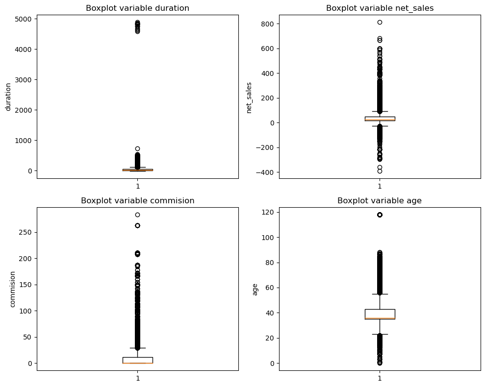

```python
# Boxplot (Variables numéricas)

# Creamos subplots
fig, axs = plt.subplots(2, 2, figsize=(10, 8))

# Boxplot de duration
axs[0, 0].boxplot(df["duration"])
axs[0, 0].set_title("Boxplot variable duration")
axs[0, 0].set_ylabel("duration")

# Boxplot de net_sales
axs[0, 1].boxplot(df["net_sales"])
axs[0, 1].set_title("Boxplot variable net_sales")
axs[0, 1].set_ylabel("net_sales")

# Boxplot de commision
axs[1, 0].boxplot(df["commision"])
axs[1, 0].set_title("Boxplot variable commision")
axs[1, 0].set_ylabel("commision")

# Boxplot de age
axs[1, 1].boxplot(df["age"])
axs[1, 1].set_title("Boxplot variable age")
axs[1, 1].set_ylabel("age")

plt.tight_layout()

# Mostramos el gráfico
plt.show()
```

- Limpieza variable **duration**:

```python
# Valor máximo duración del contrato.
print("Valor máximo duración del contrato:")
df["duration"].max()
```

```
Valor máximo duración del contrato:
```

```
4881
```

```python
df[df["duration"] > 1000]
```

|  | agency | agency_type | distribution_channel | product_name | claim | duration | destination | net_sales | commision | gender | age |
| --- | --- | --- | --- | --- | --- | --- | --- | --- | --- | --- | --- |
| 3025 | SSI | Airlines | Online | Ticket Protector | No | 4881 | SINGAPORE | 0.13 | 0.04 | Desconocido | 48 |
| 6847 | SSI | Airlines | Online | Ticket Protector | No | 4857 | SINGAPORE | 0.32 | 0.09 | Desconocido | 48 |
| 8686 | SSI | Airlines | Online | Ticket Protector | No | 4847 | SINGAPORE | 0.32 | 0.09 | Desconocido | 48 |
| 9232 | SSI | Airlines | Online | Ticket Protector | No | 4844 | SINGAPORE | 0.32 | 0.09 | Desconocido | 48 |
| 12059 | SSI | Airlines | Online | Ticket Protector | No | 4831 | SINGAPORE | 0.32 | 0.09 | Desconocido | 48 |
| 12438 | SSI | Airlines | Online | Ticket Protector | No | 4829 | SINGAPORE | 0.32 | 0.09 | Desconocido | 48 |
| 15281 | SSI | Airlines | Online | Ticket Protector | No | 4815 | SINGAPORE | 0.32 | 0.09 | Desconocido | 48 |
| 21916 | SSI | Airlines | Online | Ticket Protector | No | 4784 | SINGAPORE | 0.32 | 0.09 | Desconocido | 48 |
| 30437 | SSI | Airlines | Online | Ticket Protector | No | 4738 | SINGAPORE | 0.32 | 0.09 | Desconocido | 48 |
| 30826 | SSI | Airlines | Online | Ticket Protector | No | 4736 | SINGAPORE | 0.32 | 0.09 | Desconocido | 48 |
| 39842 | SSI | Airlines | Online | Ticket Protector | No | 4685 | SINGAPORE | 0.32 | 0.09 | Desconocido | 48 |
| 41391 | SSI | Airlines | Online | Ticket Protector | No | 4652 | SINGAPORE | 0.32 | 0.09 | Desconocido | 48 |
| 49722 | SSI | Airlines | Online | Ticket Protector | No | 4609 | SINGAPORE | 0.32 | 0.09 | Desconocido | 48 |
| 55326 | SSI | Airlines | Online | Ticket Protector | No | 4580 | SINGAPORE | 0.32 | 0.09 | Desconocido | 48 |

```python
df = df[df["duration"] < 1000]
```

Vemos que son 5 líneas de la base de datos las que tienen esta duración de días negativos, las 5 vienen de la misma agencia y el mismo tipo de agencia pero observamos un dato bastante relevante a considerarlos anómalos y plantearnos borrar directamente estas 5 líneas y es que la edad de la persona asegurada es de 118 años, por lo que procedemos a eliminar directamente estas líneas. Posteriormente, se analizarán estos valores de edad marcados con 118 años. Se actualiza el dataframe sin tener en cuenta las líneas menor a 0 días de duración.

```python
df[df["duration"] < 0]
```

|  | agency | agency_type | distribution_channel | product_name | claim | duration | destination | net_sales | commision | gender | age |
| --- | --- | --- | --- | --- | --- | --- | --- | --- | --- | --- | --- |
| 14943 | JZI | Airlines | Online | Basic Plan | No | -2 | BANGLADESH | 22.0 | 7.7 | M | 118 |
| 52587 | JZI | Airlines | Online | Basic Plan | No | -1 | MALAYSIA | 18.0 | 6.3 | Desconocido | 118 |
| 52588 | JZI | Airlines | Online | Basic Plan | No | -1 | BRUNEI DARUSSALAM | 18.0 | 6.3 | Desconocido | 118 |
| 56668 | JZI | Airlines | Online | Basic Plan | No | -1 | INDONESIA | 18.0 | 6.3 | Desconocido | 118 |
| 59528 | JZI | Airlines | Online | Basic Plan | No | -1 | CHINA | 22.0 | 7.7 | Desconocido | 118 |

```python
df = df[df["duration"] >= 0]
```

Por último, en esta variable observamos el resto de columnas para los viajes con duración de 0 días. Cada columna tiene valores normales a nivel general y considerando que hay servicios que pueden ser contratados para que solo cubra en caso de pérdida del billete de tren o transporte solicitado es probable que estos tengan menos duración de 1 día y por ello son indicados por la empresa como 0 días de duración.

```python
df[df["duration"] == 0]
```

|  | agency | agency_type | distribution_channel | product_name | claim | duration | destination | net_sales | commision | gender | age |
| --- | --- | --- | --- | --- | --- | --- | --- | --- | --- | --- | --- |
| 911 | RAB | Airlines | Online | Value Plan | No | 0 | BRUNEI DARUSSALAM | 15.00 | 6.00 | F | 24 |
| 2515 | JZI | Airlines | Online | Basic Plan | No | 0 | MYANMAR | 18.00 | 6.30 | F | 26 |
| 2868 | JZI | Airlines | Online | Basic Plan | No | 0 | INDONESIA | 18.00 | 6.30 | M | 42 |
| 3282 | RAB | Airlines | Online | Value Plan | No | 0 | BRUNEI DARUSSALAM | 15.00 | 6.00 | M | 38 |
| 3577 | SSI | Airlines | Online | Ticket Protector | No | 0 | SINGAPORE | 14.40 | 4.04 | Desconocido | 48 |
| ... | ... | ... | ... | ... | ... | ... | ... | ... | ... | ... | ... |
| 55499 | SSI | Airlines | Online | Ticket Protector | No | 0 | SINGAPORE | 3.34 | 0.94 | Desconocido | 48 |
| 57114 | RAB | Airlines | Online | Value Plan | No | 0 | BRUNEI DARUSSALAM | 15.00 | 6.00 | Desconocido | 33 |
| 60746 | SSI | Airlines | Online | Ticket Protector | No | 0 | SINGAPORE | 4.88 | 1.37 | Desconocido | 48 |
| 63097 | C2B | Airlines | Online | Bronze Plan | No | 0 | SINGAPORE | 27.00 | 6.75 | M | 23 |
| 63307 | SSI | Airlines | Online | Ticket Protector | No | 0 | SINGAPORE | 0.51 | 0.14 | Desconocido | 48 |

61 rows × 11 columns

Continuamos con la siguiente variable númerica **net_sales** y analizamos si tiene valores extremos.

- Limpieza variable **net_sales**:

En el boxplot se observa que hay muchos puntos por debajo de 0, se calcula un total de 678 valores y al representar apenas el 1% de la muestra no se van a tener en cuenta estos valores de ventas con el fin de evitar distorsiones en el modelado.

```python
ingresos_menores_cero = df[df["net_sales"] < 0]
ingresos_menores_cero.count()
```

```
agency                  678
agency_type             678
distribution_channel    678
product_name            678
claim                   678
duration                678
destination             678
net_sales               678
commision               678
gender                  678
age                     678
dtype: int64
```

```python
porcentaje_menor_cero = (df["net_sales"] < 0).mean() * 100

porcentaje_mayor_cero = (df["net_sales"] > 0).mean() * 100

print(f"Porcentaje de valores menores a 0: {porcentaje_menor_cero:.2f}%")
print(f"Porcentaje de valores mayores a 0: {porcentaje_mayor_cero:.2f}%")
```

```
Porcentaje de valores menores a 0: 1.07%
Porcentaje de valores mayores a 0: 95.95%
```

```python
df = df[df["net_sales"] > 0]
```

Se observa en el boxplot un punto destacado por encima de 700. El asegurado tiene una edad de 118 años, por lo que procede eliminarlo.

```python
df[df["net_sales"] > 700]
```

|  | agency | agency_type | distribution_channel | product_name | claim | duration | destination | net_sales | commision | gender | age |
| --- | --- | --- | --- | --- | --- | --- | --- | --- | --- | --- | --- |
| 13195 | JZI | Airlines | Online | Value Plan | No | 139 | UNITED STATES | 810.0 | 283.5 | F | 118 |

```python
df = df[df["net_sales"] < 700]
```

- Limpieza variable **commision**:

```python
df[df["commision"] >= 200]
```

|  | agency | agency_type | distribution_channel | product_name | claim | duration | destination | net_sales | commision | gender | age |
| --- | --- | --- | --- | --- | --- | --- | --- | --- | --- | --- | --- |
| 36024 | LWC | Travel Agency | Online | Annual Travel Protect Platinum | No | 395 | UNITED STATES | 323.00 | 209.95 | F | 54 |
| 36227 | LWC | Travel Agency | Online | Annual Travel Protect Gold | Yes | 397 | UNITED STATES | 320.00 | 208.00 | F | 44 |
| 37080 | LWC | Travel Agency | Online | Annual Travel Protect Platinum | No | 364 | UNITED STATES | 323.00 | 209.95 | M | 49 |
| 37266 | LWC | Travel Agency | Online | Annual Travel Protect Platinum | No | 393 | UNITED STATES | 323.00 | 209.95 | M | 44 |
| 37706 | LWC | Travel Agency | Online | Annual Travel Protect Platinum | No | 385 | UNITED STATES | 404.00 | 262.60 | F | 30 |
| 38600 | LWC | Travel Agency | Online | Annual Travel Protect Gold | No | 365 | UNITED STATES | 320.00 | 208.00 | F | 33 |
| 39631 | LWC | Travel Agency | Online | Annual Travel Protect Platinum | No | 366 | UNITED STATES | 404.00 | 262.60 | F | 53 |
| 41587 | LWC | Travel Agency | Online | Annual Travel Protect Gold | No | 367 | UNITED STATES | 320.25 | 208.16 | M | 32 |
| 42346 | LWC | Travel Agency | Online | Annual Travel Protect Gold | No | 367 | UNITED STATES | 320.25 | 208.16 | M | 55 |
| 43334 | LWC | Travel Agency | Online | Annual Travel Protect Platinum | No | 364 | UNITED STATES | 404.25 | 262.76 | M | 44 |
| 47947 | LWC | Travel Agency | Online | Annual Travel Protect Gold | No | 368 | UNITED STATES | 320.25 | 208.16 | F | 40 |
| 47948 | LWC | Travel Agency | Online | Annual Travel Protect Gold | Yes | 368 | UNITED STATES | 320.25 | 208.16 | M | 33 |
| 49870 | LWC | Travel Agency | Online | Annual Travel Protect Platinum | No | 364 | UNITED STATES | 323.40 | 210.21 | F | 58 |
| 50040 | LWC | Travel Agency | Online | Annual Travel Protect Platinum | No | 366 | UNITED STATES | 323.40 | 210.21 | M | 42 |
| 50307 | LWC | Travel Agency | Online | Annual Travel Protect Platinum | Yes | 365 | UNITED STATES | 323.40 | 210.21 | M | 48 |
| 50899 | LWC | Travel Agency | Online | Annual Travel Protect Platinum | No | 371 | UNITED STATES | 323.40 | 210.21 | M | 32 |
| 51803 | LWC | Travel Agency | Online | Annual Travel Protect Platinum | Yes | 417 | UNITED STATES | 323.40 | 210.21 | M | 30 |
| 52014 | LWC | Travel Agency | Online | Annual Travel Protect Platinum | No | 387 | UNITED STATES | 323.40 | 210.21 | F | 32 |
| 54476 | LWC | Travel Agency | Online | Annual Travel Protect Platinum | No | 364 | UNITED STATES | 323.40 | 210.21 | F | 43 |
| 54678 | LWC | Travel Agency | Online | Annual Travel Protect Platinum | No | 382 | UNITED STATES | 323.40 | 210.21 | M | 38 |
| 54679 | LWC | Travel Agency | Online | Annual Travel Protect Platinum | No | 381 | UNITED STATES | 323.40 | 210.21 | F | 41 |
| 54680 | LWC | Travel Agency | Online | Annual Travel Protect Platinum | No | 382 | UNITED STATES | 323.40 | 210.21 | F | 35 |
| 55122 | LWC | Travel Agency | Online | Annual Travel Protect Platinum | No | 393 | UNITED STATES | 323.40 | 210.21 | M | 37 |
| 55314 | LWC | Travel Agency | Online | Annual Travel Protect Platinum | No | 386 | UNITED STATES | 323.40 | 210.21 | M | 27 |
| 55687 | LWC | Travel Agency | Online | Annual Travel Protect Platinum | No | 373 | UNITED STATES | 323.40 | 210.21 | F | 34 |
| 56060 | LWC | Travel Agency | Online | Annual Travel Protect Platinum | No | 389 | UNITED STATES | 323.40 | 210.21 | M | 38 |
| 56427 | LWC | Travel Agency | Online | Annual Travel Protect Platinum | No | 365 | UNITED STATES | 323.40 | 210.21 | M | 52 |
| 56431 | LWC | Travel Agency | Online | Annual Travel Protect Platinum | No | 364 | UNITED STATES | 323.40 | 210.21 | M | 34 |
| 56625 | LWC | Travel Agency | Online | Annual Travel Protect Platinum | No | 387 | UNITED STATES | 323.40 | 210.21 | M | 42 |
| 56626 | LWC | Travel Agency | Online | Annual Travel Protect Platinum | No | 365 | UNITED STATES | 323.40 | 210.21 | M | 40 |
| 56627 | LWC | Travel Agency | Online | Annual Travel Protect Platinum | No | 427 | UNITED STATES | 323.40 | 210.21 | F | 39 |
| 56633 | LWC | Travel Agency | Online | Annual Travel Protect Platinum | No | 416 | UNITED STATES | 323.40 | 210.21 | F | 60 |
| 57115 | LWC | Travel Agency | Online | Annual Travel Protect Platinum | Yes | 368 | UNITED STATES | 323.40 | 210.21 | F | 39 |
| 57703 | LWC | Travel Agency | Online | Annual Travel Protect Platinum | No | 378 | UNITED STATES | 404.25 | 262.76 | M | 45 |
| 58504 | LWC | Travel Agency | Online | Annual Travel Protect Platinum | No | 365 | UNITED STATES | 404.25 | 262.76 | M | 58 |
| 60384 | LWC | Travel Agency | Online | Annual Travel Protect Gold | No | 365 | UNITED STATES | 320.25 | 208.16 | M | 30 |
| 60386 | LWC | Travel Agency | Online | Annual Travel Protect Gold | No | 368 | UNITED STATES | 320.25 | 208.16 | M | 36 |
| 60564 | LWC | Travel Agency | Online | Annual Travel Protect Platinum | No | 365 | UNITED STATES | 404.25 | 262.76 | M | 42 |
| 60736 | LWC | Travel Agency | Online | Annual Travel Protect Platinum | No | 371 | UNITED STATES | 404.25 | 262.76 | F | 38 |
| 60737 | LWC | Travel Agency | Online | Annual Travel Protect Platinum | No | 369 | UNITED STATES | 404.25 | 262.76 | F | 51 |
| 61189 | LWC | Travel Agency | Online | Annual Travel Protect Platinum | No | 382 | UNITED STATES | 323.40 | 210.21 | M | 36 |
| 61190 | LWC | Travel Agency | Online | Annual Travel Protect Platinum | No | 368 | UNITED STATES | 323.40 | 210.21 | M | 38 |
| 61378 | LWC | Travel Agency | Online | Annual Travel Protect Platinum | No | 368 | UNITED STATES | 323.40 | 210.21 | M | 40 |
| 61379 | LWC | Travel Agency | Online | Annual Travel Protect Platinum | No | 380 | UNITED STATES | 323.40 | 210.21 | M | 62 |
| 61391 | LWC | Travel Agency | Online | Annual Travel Protect Platinum | No | 364 | UNITED STATES | 323.40 | 210.21 | F | 37 |
| 61586 | LWC | Travel Agency | Online | Annual Travel Protect Platinum | No | 366 | UNITED STATES | 323.40 | 210.21 | M | 47 |
| 61587 | LWC | Travel Agency | Online | Annual Travel Protect Platinum | No | 450 | UNITED STATES | 323.40 | 210.21 | F | 44 |
| 61588 | LWC | Travel Agency | Online | Annual Travel Protect Platinum | No | 366 | UNITED STATES | 323.40 | 210.21 | F | 45 |
| 61589 | LWC | Travel Agency | Online | Annual Travel Protect Platinum | No | 370 | UNITED STATES | 323.40 | 210.21 | M | 51 |
| 61590 | LWC | Travel Agency | Online | Annual Travel Protect Platinum | No | 390 | UNITED STATES | 323.40 | 210.21 | M | 55 |
| 61788 | LWC | Travel Agency | Online | Annual Travel Protect Platinum | No | 366 | UNITED STATES | 323.40 | 210.21 | F | 37 |
| 61802 | LWC | Travel Agency | Online | Annual Travel Protect Platinum | No | 364 | UNITED STATES | 323.40 | 210.21 | F | 42 |
| 62088 | LWC | Travel Agency | Online | Annual Travel Protect Platinum | No | 364 | UNITED STATES | 323.40 | 210.21 | M | 39 |
| 62342 | LWC | Travel Agency | Online | Annual Travel Protect Platinum | No | 365 | UNITED STATES | 323.40 | 210.21 | F | 39 |
| 62343 | LWC | Travel Agency | Online | Annual Travel Protect Platinum | No | 374 | UNITED STATES | 323.40 | 210.21 | M | 52 |
| 62348 | LWC | Travel Agency | Online | Annual Travel Protect Platinum | No | 374 | UNITED STATES | 323.40 | 210.21 | M | 35 |
| 62737 | LWC | Travel Agency | Online | Annual Travel Protect Platinum | No | 387 | UNITED STATES | 323.40 | 210.21 | F | 55 |
| 62738 | LWC | Travel Agency | Online | Annual Travel Protect Platinum | No | 408 | UNITED STATES | 323.40 | 210.21 | F | 36 |

```python
df = df[df["commision"] <= 280]
```

Por último, analizamos la variable numérica **age**.

- Limpieza variable **age**:

En el boxplot se observan algunos valores por encima de 100 años, posibles valores atípicos y algunos muy próximos a 0 que también se van a analizar para ver si pueden ser considerados como anómalos y tenemos que hacer algunas modificaciones. Visualizamos 10 casos con edad superior a 100 años y vemos que todos vienen determinados con 118 años, esto puede indicar que las compañías de seguros ponen este valor quizás cuando la edad es desconocida.

```python
df[df["age"]>100].head(10)
```

|  | agency | agency_type | distribution_channel | product_name | claim | duration | destination | net_sales | commision | gender | age |
| --- | --- | --- | --- | --- | --- | --- | --- | --- | --- | --- | --- |
| 105 | JWT | Airlines | Online | Value Plan | No | 11 | INDIA | 50.0 | 20.00 | M | 118 |
| 220 | JWT | Airlines | Online | Value Plan | No | 4 | INDIA | 62.0 | 24.80 | F | 118 |
| 367 | JWT | Airlines | Online | Value Plan | No | 16 | INDIA | 50.0 | 20.00 | M | 118 |
| 402 | CCR | Travel Agency | Offline | Comprehensive Plan | No | 5 | MALAYSIA | 29.0 | 9.57 | M | 118 |
| 403 | CCR | Travel Agency | Offline | Comprehensive Plan | No | 5 | MALAYSIA | 29.0 | 9.57 | F | 118 |
| 404 | CCR | Travel Agency | Offline | Comprehensive Plan | No | 5 | MALAYSIA | 29.0 | 9.57 | M | 118 |
| 562 | JWT | Airlines | Online | Value Plan | No | 10 | INDIA | 31.0 | 12.40 | M | 118 |
| 564 | JWT | Airlines | Online | Value Plan | No | 7 | INDIA | 62.0 | 24.80 | M | 118 |
| 565 | JWT | Airlines | Online | Value Plan | No | 12 | INDIA | 60.0 | 24.00 | M | 118 |
| 566 | JWT | Airlines | Online | Value Plan | No | 15 | INDIA | 50.0 | 20.00 | M | 118 |

```python
df[df["age"]>100].count()
```

```
agency                  947
agency_type             947
distribution_channel    947
product_name            947
claim                   947
duration                947
destination             947
net_sales               947
commision               947
gender                  947
age                     947
dtype: int64
```

```python
porcentaje_mayor_cien = (df["age"] > 100).mean() * 100
print(f"Porcentaje de valores mayores a 100 en edad: {porcentaje_mayor_cien:.2f}%")
```

```
Porcentaje de valores mayores a 100 en edad: 1.56%
```

Obtenemos un total de 947 casos con edad igual a 118 años que supone un 1,56% de valores de la muestra, una representación pequeña. Se actualiza el dataset sin tener en cuenta estos valores extremos.

```python
df = df[df["age"] < 100]
```

Ahora, vamos a proceder a analizar también los valores menores a 10 años, vemos que hay un valor = 0 que sería raro que a un niño con menos de 1 año le pusieran un seguro de este tipo, por ello este valor es considerado como atípico. Luego, obtenemos algunos valores de 1,2 y 3 años de edad también posibles considerados como atípicos pero como puede ser que sea para el contrato de servicios muy específicos en viajes dónde si lo necesitan vamos a considerarlos no atípicos. Lo razonable sería en estos casos contratar el producto "Child Comprehensive Plan" pero es posible que algunos viajes con características muy específicas tengan que contratar otro servicio o que algunas compañías de seguros no dispongan de este producto.

```python
df[df["age"]<10]
```

|  | agency | agency_type | distribution_channel | product_name | claim | duration | destination | net_sales | commision | gender | age |
| --- | --- | --- | --- | --- | --- | --- | --- | --- | --- | --- | --- |
| 5313 | CSR | Travel Agency | Offline | Comprehensive Plan | No | 43 | MALAYSIA | 29.00 | 9.57 | F | 8 |
| 10575 | CCR | Travel Agency | Offline | Comprehensive Plan | No | 282 | MALAYSIA | 29.00 | 9.57 | F | 9 |
| 14362 | C2B | Airlines | Online | Silver Plan | No | 17 | SINGAPORE | 81.00 | 20.25 | F | 3 |
| 14945 | C2B | Airlines | Online | Silver Plan | No | 5 | SINGAPORE | 27.75 | 6.94 | M | 9 |
| 17021 | JZI | Airlines | Online | Value Plan | No | 2 | MALAYSIA | 26.00 | 9.10 | F | 1 |
| 22481 | C2B | Airlines | Online | Silver Plan | No | 6 | SINGAPORE | 31.85 | 7.96 | M | 9 |
| 23547 | CCR | Travel Agency | Offline | Premier Plan | No | 8 | THAILAND | 58.00 | 19.14 | F | 5 |
| 25278 | CBH | Travel Agency | Offline | Comprehensive Plan | No | 29 | MALAYSIA | 29.00 | 9.57 | F | 8 |
| 32606 | C2B | Airlines | Online | Silver Plan | No | 3 | SINGAPORE | 18.50 | 4.63 | M | 2 |
| 36390 | TTW | Travel Agency | Offline | Child Comprehensive Plan | No | 369 | SINGAPORE | 74.00 | 0.00 | M | 9 |
| 36391 | TTW | Travel Agency | Offline | Child Comprehensive Plan | No | 369 | SINGAPORE | 74.00 | 0.00 | F | 5 |
| 36392 | TTW | Travel Agency | Offline | Child Comprehensive Plan | No | 369 | SINGAPORE | 74.00 | 0.00 | M | 9 |
| 36549 | TTW | Travel Agency | Offline | Child Comprehensive Plan | No | 365 | SINGAPORE | 74.00 | 0.00 | M | 3 |
| 38658 | C2B | Airlines | Online | Silver Plan | No | 155 | SINGAPORE | 319.00 | 79.75 | M | 4 |
| 39665 | CCR | Travel Agency | Offline | Comprehensive Plan | No | 50 | THAILAND | 29.00 | 9.57 | F | 8 |
| 41427 | C2B | Airlines | Online | Bronze Plan | No | 17 | SINGAPORE | 39.00 | 9.75 | F | 5 |
| 41993 | TST | Travel Agency | Offline | Travel Cruise Protect | No | 94 | THAILAND | 30.00 | 10.50 | F | 0 |
| 42037 | C2B | Airlines | Online | Bronze Plan | No | 29 | SINGAPORE | 56.50 | 14.13 | M | 3 |
| 42611 | TST | Travel Agency | Offline | Travel Cruise Protect | No | 64 | THAILAND | 30.00 | 10.50 | F | 3 |
| 44035 | CCR | Travel Agency | Offline | Comprehensive Plan | No | 30 | THAILAND | 29.00 | 9.57 | F | 7 |
| 47208 | TST | Travel Agency | Offline | Travel Cruise Protect | No | 40 | THAILAND | 30.00 | 10.50 | M | 7 |
| 47976 | TST | Travel Agency | Offline | Travel Cruise Protect | No | 58 | THAILAND | 30.00 | 10.50 | F | 8 |
| 48202 | TST | Travel Agency | Offline | Travel Cruise Protect | No | 38 | MALAYSIA | 30.00 | 10.50 | F | 7 |
| 52066 | TST | Travel Agency | Offline | Travel Cruise Protect | No | 24 | MALAYSIA | 30.00 | 10.50 | F | 9 |
| 52796 | TST | Travel Agency | Offline | Travel Cruise Protect | No | 5 | THAILAND | 30.00 | 10.50 | F | 7 |
| 57555 | C2B | Airlines | Online | Silver Plan | No | 10 | SINGAPORE | 46.80 | 11.70 | M | 1 |
| 57748 | C2B | Airlines | Online | Silver Plan | No | 33 | SINGAPORE | 74.40 | 18.60 | M | 1 |
| 58185 | TST | Travel Agency | Offline | Travel Cruise Protect | No | 14 | THAILAND | 30.00 | 10.50 | M | 8 |
| 58546 | C2B | Airlines | Online | Bronze Plan | No | 7 | SINGAPORE | 20.00 | 5.00 | F | 8 |
| 60234 | C2B | Airlines | Online | Bronze Plan | No | 12 | SINGAPORE | 16.00 | 4.00 | M | 1 |
| 62443 | EPX | Travel Agency | Online | 2 way Comprehensive Plan | No | 6 | MALAYSIA | 21.00 | 0.00 | Desconocido | 7 |
| 63211 | C2B | Airlines | Online | Bronze Plan | No | 56 | SINGAPORE | 86.50 | 21.63 | F | 1 |

```python
df = df[df["age"] > 0]
```

Por último, vamos a transformar la variable objetivo **Claim** que nos determina si ha habido siniestro o no, a binaria de tal forma que Yes = 1 y No = 0. Utilizamos la función **replace()**.

```python
df["claim"] = df["claim"].replace({"Yes":1,"No":0})
```

Tras realizar la limpieza de datos vamos a revisar que nuestro dataframe con el que se realizarán los modelos y diferentes análisis no haya sido modificado en exceso a nivel de cantidad de muestra. El resultado es de 59.796 entradas, un muestra grande para poder trabajar.

```python
df.shape
```

```
(59796, 11)
```

### 1.3 Análisis estadístico descriptivo y frecuencias absolutas.

- **Variable objetivo (Claim)**:

```
Frecuencias de la variable claim:
 claim
0    58882
1      914
Name: count, dtype: int64
Porcentaje de 'Yes': 1.53%
Porcentaje de 'No': 98.47%
```

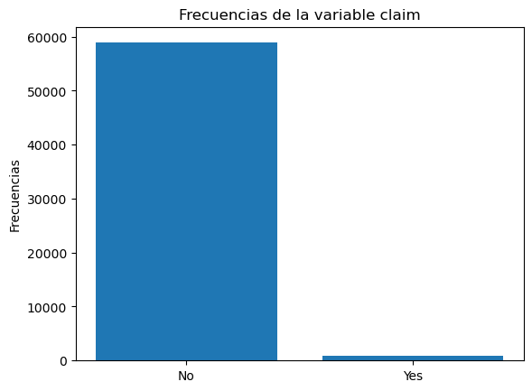

```python
# Calculamos el nivel de frecuencia para los siniestros, 1 (Yes) y 0 (No)
frecuencia_claim = df["claim"].value_counts()
total_registros_claim = len(df)
# Calculamos los porcentajes
porcentaje_yes = (frecuencia_claim[1] / total_registros_claim) * 100
porcentaje_no = (frecuencia_claim[0] / total_registros_claim) * 100
print("Frecuencias de la variable claim:\n", frecuencia_claim)
print(f"Porcentaje de 'Yes': {porcentaje_yes:.2f}%")
print(f"Porcentaje de 'No': {porcentaje_no:.2f}%")
# Ahora realizamos el gráfico para la variable claim
plt.bar(frecuencia_claim.index.values, frecuencia_claim)
plt.xticks(frecuencia_claim.index.values, ("No", "Yes"))
plt.ylabel("Frecuencias")
plt.title("Frecuencias de la variable claim")
```

- **Variables categóricas o cualitativas (agency, agency_type, distribution_channel, product_name, destination, gender):**

Se visualiza la frecuencia absoluta para cada una de las variables cualitativas.

```
Frecuencia de valores para agency:
agency
EPX    34344
C2B     8080
CWT     7218
JZI     6113
SSI     1024
RAB      715
LWC      661
TST      518
KML      388
ART      259
CCR      144
TTW       98
CBH       94
CSR       86
ADM       54
Name: count, dtype: int64

Frecuencia de valores para agency_type:
agency_type
Travel Agency    43605
Airlines         16191
Name: count, dtype: int64

Frecuencia de valores para distribution_channel:
distribution_channel
Online     58813
Offline      983
Name: count, dtype: int64

Frecuencia de valores para product_name:
product_name
Cancellation Plan                       18211
2 way Comprehensive Plan                12874
Rental Vehicle Excess Insurance          7218
Basic Plan                               5305
Bronze Plan                              3967
1 way Comprehensive Plan                 3259
Silver Plan                              2206
```

[output cut: 26 more lines]

```
INDONESIA                  3377
                          ...
MOLDOVA                       1
GUADELOUPE                    1
NEW CALEDONIA                 1
ARMENIA                       1
BOSNIA AND HERZEGOVINA        1
Name: count, Length: 145, dtype: int64

Frecuencia de valores para gender:
gender
Desconocido    42840
M               8588
F               8368
Name: count, dtype: int64
```

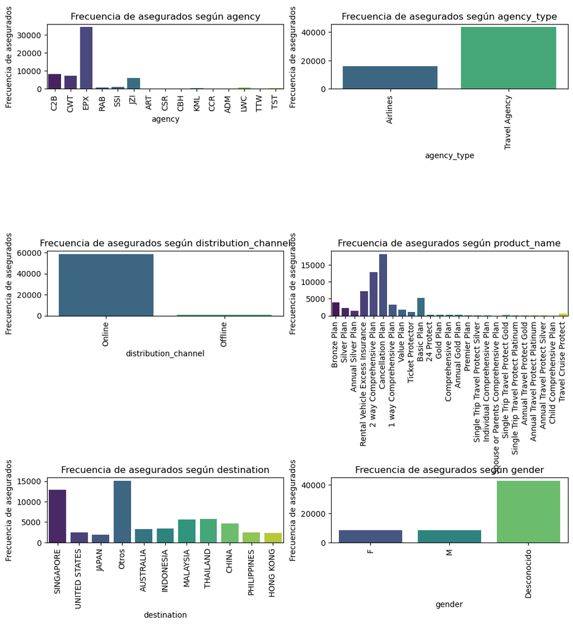

```python
# Se crea una lista de variables categóricas.
variables_categoricas = ["agency", "agency_type", "distribution_channel", "product_name", "destination", "gender"]

# Se calcula y visualizamos las frecuencias de cada valor para cada variable categórica.
for variable in variables_categoricas:
    frecuencia = df[variable].value_counts()
    print(f"Frecuencia de valores para {variable}:\n{frecuencia}\n")

# Se muestran dos variables por fila y el espacio configurado entre fila y fila con hspace.
fig, axes = plt.subplots(3, 2, figsize=(12, 12))
fig.subplots_adjust(hspace=2.5)

# Ahora se visualiza las frecuencias para cada variable categórica en un diagrama de barras. Para la variable destination como son muchos los valores diferentes,
# solo se proceden a mostrar el top10 de destination más visitados.
for ax, variable in zip(axes.flatten(), variables_categoricas):
    if variable == "destination":
# Se filtran solo los top 10 destinos más comunes utilizando isin para mostrar una serie de boleanos que indica si el valor de la variable destination está en el top 10 y where
# para reemplazar el valor de la columna cuando no se cumpla la condición del top10 por otros para su visalualización.
        top_10_destinos = df["destination"].value_counts().head(10).index
        df_destination = df.copy()
        df_destination[variable] = df_destination[variable].where(df_destination[variable].isin(top_10_destinos), "Otros")
        sns.countplot(x=variable, data=df_destination, palette="viridis", ax=ax)
    else:
        sns.countplot(x=variable, data=df, palette="viridis", ax=ax)
# Frecuencia de asegurados según las variables cualitativas en términos reales.
    ax.set_title(f"Frecuencia de asegurados según {variable}")
    ax.set_xlabel(variable)
    ax.set_ylabel("Frecuencia de asegurados")
    ax.tick_params(axis="x", rotation=90)
plt.show()
```

- **Variables numéricas:**

```python
# Utilzamos la función describe() oara visualizar en una tabla la estadística descriptiva básica y se seleccionan solo las variables numéricas en una lista.
variables_numericas = ["duration", "net_sales", "commision", "age"]
df_numericas = df[variables_numericas]
descriptivas_basicas = df_numericas.describe()

print(f"Estadísticas descriptivas para las variables numéricas:\n {descriptivas_basicas}")
```

```
Estadísticas descriptivas para las variables numéricas:
            duration     net_sales     commision           age
count  59796.000000  59796.000000  59796.000000  59796.000000
mean      48.153589     42.970903      9.186274     38.739397
std       74.134609     47.824717     19.459212     10.068143
min        0.000000      0.190000      0.000000      1.000000
25%        9.000000     19.800000      0.000000     35.000000
50%       22.000000     27.000000      0.000000     36.000000
75%       52.000000     49.500000      9.750000     42.000000
max      547.000000    682.000000    262.760000     88.000000
```

### 1.4. Distribución y análisis (Variable cualitativa -- Variable objetivo).

Tras haber realizado una primera visualización de las frecuencias de cada variable y analizarse las variables numéricas. Se estudia la vinculación que hay entre las variable categóricas y la variable objetivo claim que determina si ha habido siniestro o no. Primero realizamos una visualización de la tabla de contigencias y gráficos de barras de los valores reales para cada combinación de variable categórica-objetivo. Hay que tener en cuenta que debido al gran desequilibrio, en la mayoría de casos se obtienen unos valores bastante bajos en el gráfico para los casos de siniestro en cada subcategoría de las variables.

```
Tabla de contingencia para agency y claim:
claim       0    1  Total
agency
ADM        54    0     54
ART       259    0    259
C2B      7533  547   8080
CBH        93    1     94
CCR       142    2    144
CSR        85    1     86
CWT      7132   86   7218
EPX     34155  189  34344
JZI      6083   30   6113
KML       380    8    388
LWC       625   36    661
RAB       714    1    715
SSI      1017    7   1024
TST       516    2    518
TTW        94    4     98
Total   58882  914  59796

Tabla de contingencia para agency_type y claim:
claim              0    1  Total
agency_type
Airlines       15606  585  16191
Travel Agency  43276  329  43605
Total          58882  914  59796

Tabla de contingencia para distribution_channel y claim:
claim                     0    1  Total
distribution_channel
Offline                 971   12    983
Online                57911  902  58813
Total                 58882  914  59796

Tabla de contingencia para product_name y claim:
claim                                     0    1  Total
product_name
1 way Comprehensive Plan               3252    7   3259
2 way Comprehensive Plan              12735  139  12874
24 Protect                              233    0    233
```

[output cut: 33 more lines]

```
VIETNAM                       1628   12   1640
VIRGIN ISLAND UNITED STATES      1    0      1
ZAMBIA                           2    0      2
ZIMBABWE                         3    0      3
Total                        58882  914  59796

[146 rows x 3 columns]

Tabla de contingencia para gender y claim:
claim            0    1  Total
gender
Desconocido  42558  282  42840
F             8026  342   8368
M             8298  290   8588
Total        58882  914  59796
```

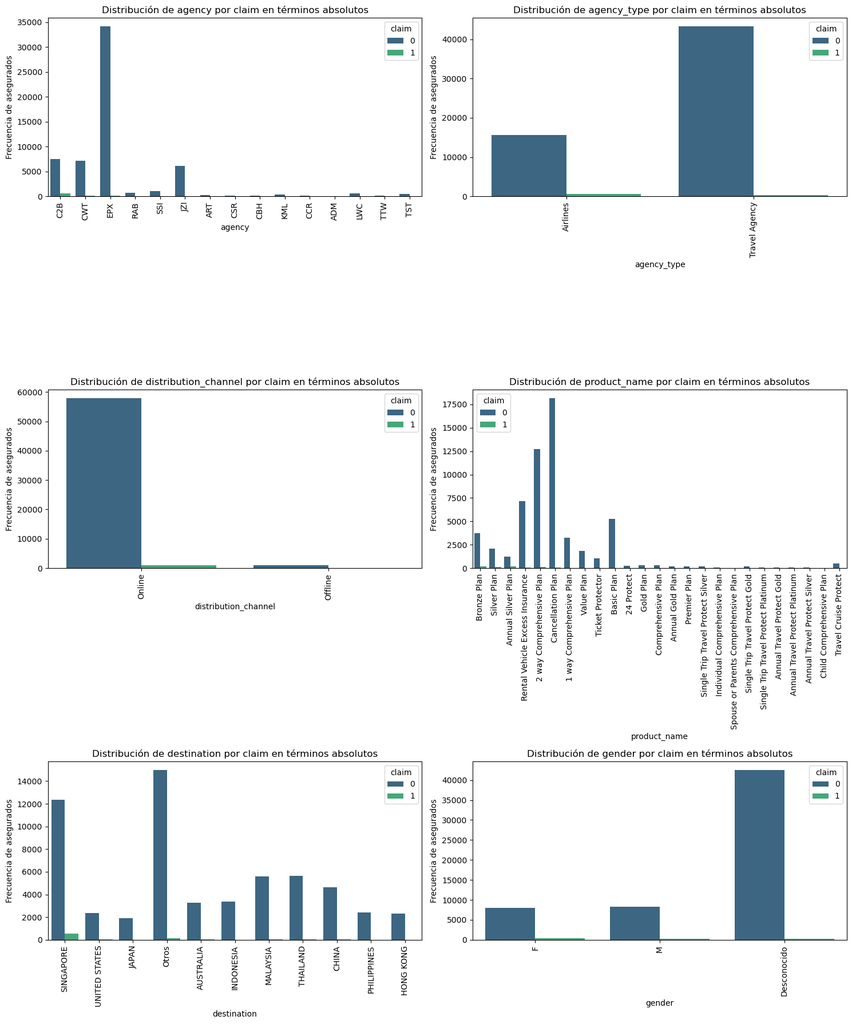

```python
# Igual que hemos creado una variable para las categóricas se crea la variable objetivo.
variable_objetivo = "claim"

# Se crea los subplots en dos por cada fila y ajustamos el espacio entre ellas como hemos realizado anteriormente, se descompactan los subplots.
fig, axes = plt.subplots(len(variables_categoricas)//2, 2, figsize=(15, 6 * (len(variables_categoricas)//2)))
fig.subplots_adjust(hspace=2.5)
axes = axes.flatten()

# Creamos una iteración sobre las variables categóricas y se realiza una tabla de contingecias de la frecuencia de las variables categóricas en base a la variable objetivo.
for i, variable in enumerate(variables_categoricas):
    tabla_contingencia = pd.crosstab(df[variable], df[variable_objetivo], margins=True, margins_name="Total")
    print(f"Tabla de contingencia para {variable} y {variable_objetivo}:\n{tabla_contingencia}\n")

# Se visualiza la relación entre variables categóricas y variable objetivo, filtrando como hemos hecho anteriormente por el top 10 en destinos y el resto de determinados como
# otros.
    if variable == "destination":
        top_10_destinos = df["destination"].value_counts().head(10).index
        df_destino = df.copy()
        df_destino["destination"] = df_destino["destination"].where(df_destino["destination"].isin(top_10_destinos), "Otros")
        sns.countplot(x=variable, hue=variable_objetivo, data=df_destino, ax=axes[i], palette="viridis")
    else:
        sns.countplot(x=variable, hue=variable_objetivo, data=df, ax=axes[i], palette="viridis")
    axes[i].set_title(f"Distribución de {variable} por {variable_objetivo} en términos absolutos")
    axes[i].set_xlabel(variable)
    axes[i].set_ylabel("Frecuencia de asegurados")
    axes[i].set_xticklabels(axes[i].get_xticklabels(), rotation=90)
plt.tight_layout()
plt.show()
```

Efectivamente, se observan valores bajos a nivel general. Para obtener un mejor criterio del perfil asegurado referente solo a los casos de siniestro. Se realiza una visualización de todas las variables cualitativas pero solo teniendo en cuenta que en la variable objetivo se ha dado el siniestro.

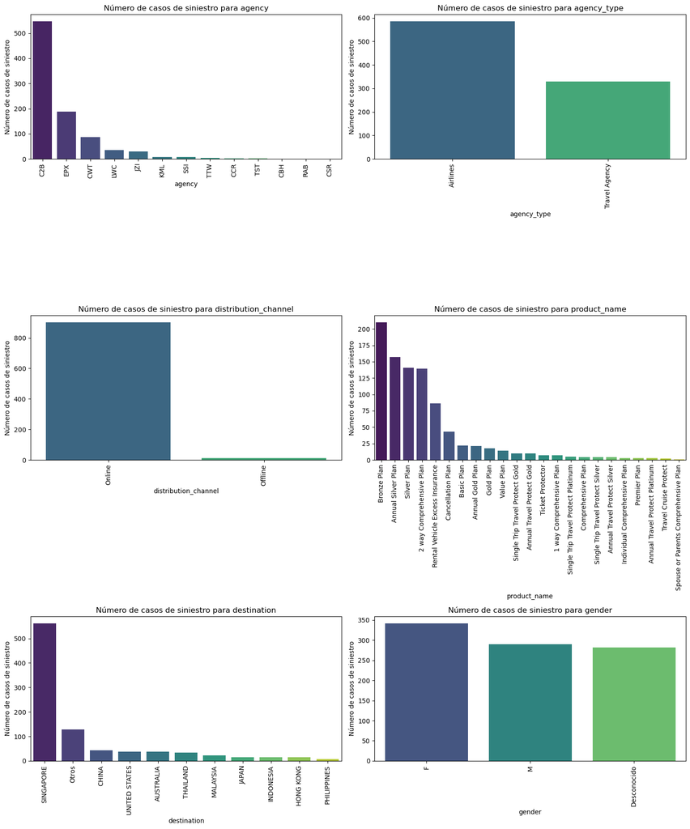

```python
# Se configura el número de gráficos por fila y creamos los subplots al igual que se ha hecho anteriormente.
num_cols = 2
num_rows = (len(variables_categoricas) + num_cols - 1) // num_cols
fig, axes = plt.subplots(num_rows, num_cols, figsize=(15, 6 * num_rows))
fig.subplots_adjust(hspace=2.5)
axes = axes.flatten()

# Iteramos sobre cada variable categórica y filtramos por el top 10 de destinos. El resto de países se consideran como "Otros".
for i, variable in enumerate(variables_categoricas):
    row = i // num_cols
    col = i % num_cols
    if variable == "destination":
        top_destinations = df["destination"].value_counts().head(10).index
        df_destination = df.copy()
        df_destination["destination"] = df_destination["destination"].where(df_destination["destination"].isin(top_destinations), "Otros")
        casos_siniestro = df_destination[df_destination[variable_objetivo] == 1][variable].value_counts()
    else:
        casos_siniestro = df[df[variable_objetivo] == 1][variable].value_counts()

# Se visualiza la cantidad de casos de siniestro para cada subcategoría.
    sns.barplot(x=casos_siniestro.index, y=casos_siniestro, ax=axes[i], palette="viridis")
    axes[i].set_title(f'Número de casos de siniestro para {variable}')
    axes[i].set_xlabel(variable)
    axes[i].set_ylabel("Número de casos de siniestro")
    axes[i].set_xticklabels(axes[i].get_xticklabels(), rotation=90)

fig.tight_layout()
plt.show()
```

- **Aspectos a destacar**:
- La empresa con un mayor número de pólizas es EPX pero sin embargo, en casos de siniestro se destaca C2B.
- En niveles absolutos se contratan más servicios a través de agencias de viaje, aunque los casos de siniestro tienen una mayor frecuencia en las aerolíneas.
- El servicio contratado de forma online predomina respecto al presencial.
- El servicio más contratado a nivel generales es el "Cancellation Plan" aunque no es el servicio más siniestrado, de hecho, tiene pocos casos. Sin embargo, el servicio Bronze Plan no tiene tantos casos en términos absolutos pero si se suele dar con mucha frecuencia la siniestralidad.
- El destino más frecuente en la base de datos en Singapore tanto en términos absolutos como teniendo en cuenta solo los casos de siniestro.
- A pesar de que en el género hay una mayor frecuencia de hombres respecto a mujeres. En los casos de siniestro, hay un porcentaje mayor de mujeres quq de hombres.

### 1.5 Análisis de correlación entre variables.

En primer lugar, se analiza la correlación existente entre los pares de variables numéricas para ver si están correlacionadas o no.

- **Matriz Correlaciones Variables Numéricas (Coeficiente Pearson)**

```
Correlación entre variables numéricas y variable objetivo (claim):
           duration  net_sales  commision       age     claim
duration   1.000000   0.667296   0.499884  0.028149  0.107096
net_sales  0.667296   1.000000   0.747412  0.033647  0.136151
commision  0.499884   0.747412   1.000000  0.110982  0.107906
age        0.028149   0.033647   0.110982  1.000000 -0.012250
claim      0.107096   0.136151   0.107906 -0.012250  1.000000
```

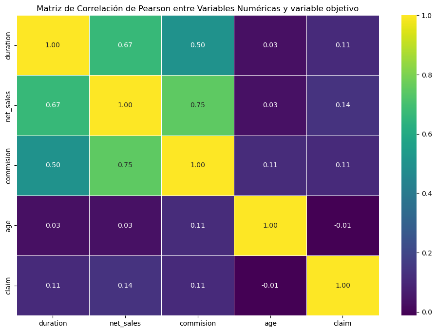

```python
# Calculamos la matriz de correlación de pearson
correlation_matrix = df[variables_numericas + [variable_objetivo]].corr()
# Se muestran las correlaciones entre las variables con un mapa de calor.
print("Correlación entre variables numéricas y variable objetivo (claim):")
print(correlation_matrix)
plt.figure(figsize=(12, 8))
sns.heatmap(correlation_matrix, annot=True, cmap="viridis", fmt=".2f", linewidths=0.5)
plt.title("Matriz de Correlación de Pearson entre Variables Numéricas y variable objetivo")
plt.show()
```

Destacamos que las variables commision y net_sales obtienen un valor de correlación de 0.75 por lo que se puede concluir que existe colinealidad entre estas dos variables, al tratarse de las ventas y comisiones tiene sentido que esten bastante relacionadas. Ante el aumento de pesos en una de las variables, la otra variable también se verá afectada.

- **Matriz Correlaciones Variables Categóricas (V de Cramer)**

```
Matriz de coeficientes de Cramer V:
                        agency agency_type distribution_channel product_name
agency                     NaN    0.999891             0.977429     0.827698  \
agency_type           0.999891         NaN             0.076747     0.989205
distribution_channel  0.977429    0.076747                  NaN      0.96996
product_name          0.827698    0.989205              0.96996          NaN
destination           0.385777    0.568841             0.215373     0.253591
gender                0.712538    0.864982             0.206428     0.711902

                     destination    gender
agency                  0.385777  0.712538
agency_type             0.568841  0.864982
distribution_channel    0.215373  0.206428
product_name            0.253591  0.711902
destination                  NaN  0.324099
gender                  0.324099       NaN
```

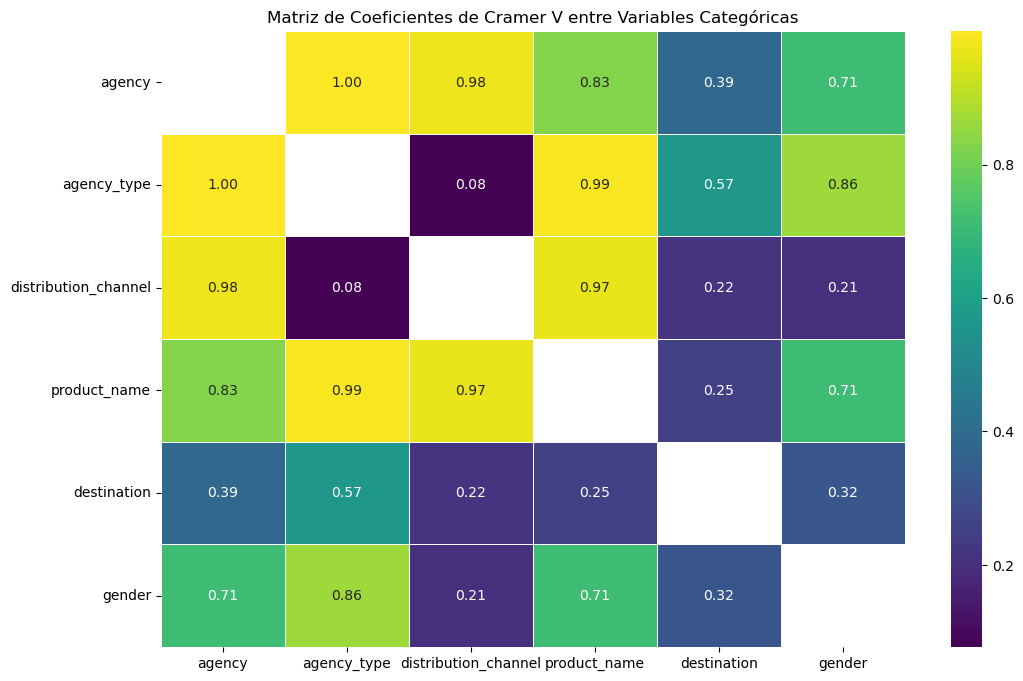

```python
# Creamos una variables con el dataframe pero solo teniendo en cuenta las variables categoricas.
df_categorico = df[variables_categoricas]

# Se crea una función para calcular el coeficiente de cramer V.
def cramers_v(confusion_cramer_matrix):
    """
    Calcula el coeficiente V de Cramer a partir de una matriz de confusión.

    :param confusion_cramer_matrix: Matriz de confusión.
    :return: Coeficiente V de Cramer.
    """
    chi2 = chi2_contingency(confusion_cramer_matrix)[0]
    n = confusion_cramer_matrix.sum().sum()
    phi2 = chi2 / n
    r, k = confusion_cramer_matrix.shape
    phi2corr = max(0, phi2 - ((k - 1) * (r - 1)) / (n - 1))
    rcorr = r - ((r - 1) ** 2) / (n - 1)
    kcorr = k - ((k - 1) ** 2) / (n - 1)
    return np.sqrt(phi2corr / min((kcorr - 1), (rcorr - 1)))

# Calculamos el coeficiente de cramer v sobre todas las combinaciones de variables categóricas.
cramer_matrix = pd.DataFrame(index=variables_categoricas, columns=variables_categoricas)

for var1 in variables_categoricas:
    for var2 in variables_categoricas:
        if var1 != var2:
            confusion_cramer_matrix = pd.crosstab(df_categorico[var1], df_categorico[var2])
            cramers_value = cramers_v(confusion_cramer_matrix.values)
            cramer_matrix.at[var1, var2] = cramers_value

# Se muestra la matriz de cramer_matrix para los coeficientes de cramer y se convierten los valores a numéricos para crear el mapa de calor.
print("Matriz de coeficientes de Cramer V:")
print(cramer_matrix)
cramer_matrix_numeric = cramer_matrix.apply(pd.to_numeric, errors="coerce")
plt.figure(figsize=(12, 8))
sns.heatmap(cramer_matrix_numeric, annot=True, cmap="viridis", fmt=".2f", linewidths=0.5)
plt.title("Matriz de Coeficientes de Cramer V entre Variables Categóricas")
plt.show()
```

La matriz de coeficientes V de Cramer proporciona la información sobre la correlación que existe entre las variables categóricas, en la diagonal principal se detecta valores Nan ya que no se comparan los coeficientes de una variable consigo misma. Como aspecto a destacar, existe colinealidad entre las variables "agency" y "agency_type" (0.99), esto quiere decir que tienen una correlación fuerte entre ellas mismas. Aunque, tenemos que tener en cuenta que se tratan de dos variables que pueden estar relacionadas al tener la misma tipología, una es el nombre de la agencia y otra el tipo.

## 2. Preparación de los datos y selección de variables.

### 2.1 Normalización de las variables categóricas (One-Ordinal-Encoding).

Primeramente, para facilitar la ejecución de los modelos futuros y su interpretación, las variables cualitativas o categóricas son transformadas a variables numéricas. Para ello, se utilizan técnicas como puede ser One-Hot-Encoding o One-Ordinal-Encoding. La variable "destination" presenta 190 subcategorías para los países de destino, entonces utilizar el método de dummies dónde se transforma cada subcategoría a variable binaria imputando 1 en el caso de que se dé la instancia o 0, en caso contrario, supondría la creación de un exceso de variables. Por ello, el método utilizado es One-Ordinal-Encoding que está basado en imputar con un número entero según la vaya apareciendo cada subcategoría.

```python
# Se crea el codificador ordinal
encoder = OrdinalEncoder()

# Se ajustan las variables categóricas con el uso del codificador
df[variables_categoricas] = encoder.fit_transform(df[variables_categoricas])

# Mostramos que se han modificado correctamente las variables categóricas a numéricas.
df[variables_categoricas].head(10)
```

|  | agency | agency_type | distribution_channel | product_name | destination | gender |
| --- | --- | --- | --- | --- | --- | --- |
| 21 | 2.0 | 0.0 | 1.0 | 9.0 | 116.0 | 1.0 |
| 22 | 2.0 | 0.0 | 1.0 | 9.0 | 116.0 | 1.0 |
| 23 | 2.0 | 0.0 | 1.0 | 9.0 | 116.0 | 2.0 |
| 24 | 2.0 | 0.0 | 1.0 | 17.0 | 116.0 | 2.0 |
| 25 | 2.0 | 0.0 | 1.0 | 4.0 | 116.0 | 1.0 |
| 26 | 6.0 | 1.0 | 1.0 | 16.0 | 136.0 | 0.0 |
| 27 | 6.0 | 1.0 | 1.0 | 16.0 | 136.0 | 0.0 |
| 28 | 6.0 | 1.0 | 1.0 | 16.0 | 62.0 | 0.0 |
| 29 | 6.0 | 1.0 | 1.0 | 16.0 | 135.0 | 0.0 |
| 30 | 6.0 | 1.0 | 1.0 | 16.0 | 135.0 | 0.0 |

Anteriormente, hemos visto que las variables cualitativas en la ejecución de la matriz con el coeficiente V de Cramer presentaba colinealidad en algunas de las variables, un método de solucionarlo es normalizar estas variables con el método utilizado para que se encuentren digamos en una misma escala.

### 2.2 Estandarización de las variables numéricas.

El proceso de estandarización se realizar sobre las variables numéricas originales del conjunto de datos con el objetivo de que tengan una media de cero y una desviación estándar de uno, para diferentes modelos como pueden ser el de árbol o el descenso gradiente esto es importante ya que son algoritmos basados en medidas de distancia y todos los datos tienen que tener la misma escala. Las variables que en el conjunto de datos original eran cualitativas o categóricas y la variable objetivo, no se deben de normalizar o estandarizar ya que el proceso de one ordinal coding ya está poniendo en la misma escala estas variables categóricas y la escala de la variable objetivo ya viene indicad como binaria.

```python
# Crea el objeto StandardScaler
scaler = StandardScaler()

# Estandariza las variables numéricas
df[variables_numericas] = scaler.fit_transform(df[variables_numericas])

# Visualiza las primeras filas del DataFrame después de la estandarización
df.head(10)
```

|  | agency | agency_type | distribution_channel | product_name | claim | duration | destination | net_sales | commision | gender | age |
| --- | --- | --- | --- | --- | --- | --- | --- | --- | --- | --- | --- |
| 21 | 2.0 | 0.0 | 1.0 | 9.0 | 0 | -0.487679 | 116.0 | 0.066474 | 0.120958 | 1.0 | 0.522504 |
| 22 | 2.0 | 0.0 | 1.0 | 9.0 | 0 | -0.555124 | 116.0 | -0.531548 | -0.246480 | 1.0 | -1.364652 |
| 23 | 2.0 | 0.0 | 1.0 | 9.0 | 1 | -0.487679 | 116.0 | 1.067011 | 0.735582 | 2.0 | -0.470736 |
| 24 | 2.0 | 0.0 | 1.0 | 17.0 | 0 | 1.913379 | 116.0 | 5.264667 | 3.314845 | 2.0 | -1.265328 |
| 25 | 2.0 | 0.0 | 1.0 | 4.0 | 0 | 4.260480 | 116.0 | 7.235422 | 4.525592 | 1.0 | -0.868032 |
| 26 | 6.0 | 1.0 | 1.0 | 16.0 | 0 | -0.258364 | 136.0 | -0.691508 | -0.166826 | 0.0 | -0.570060 |
| 27 | 6.0 | 1.0 | 1.0 | 16.0 | 0 | -0.271854 | 136.0 | -0.691508 | -0.166826 | 0.0 | -0.570060 |
| 28 | 6.0 | 1.0 | 1.0 | 16.0 | 0 | 1.414283 | 62.0 | 0.550538 | 1.664713 | 0.0 | -0.371412 |
| 29 | 6.0 | 1.0 | 1.0 | 16.0 | 0 | -0.271854 | 135.0 | -0.484500 | 0.138430 | 0.0 | -0.768708 |
| 30 | 6.0 | 1.0 | 1.0 | 16.0 | 0 | -0.595592 | 135.0 | -0.277493 | 0.443687 | 0.0 | 2.211012 |

Anteriormente, hemos visto que las variables cualitativas en la ejecución de la matriz con el coeficiente V de Cramer presentaba colinealidad en algunas de las variables, un método de solucionarlo es normalizar estas variables con el método utilizado, además también hemos estandarizado las variables numéricas. Por lo tanto, si ahora visualizaramos la correlación entre las variables ya no debería haber presencia de colinealidad.

### 2.3 Solución al desbalanceo de clases (SMOTE y RandomUndersampling).

Anteriormente, se ha visto que los datos estaban desbalanceados con respecto a la variable objetivo porque existen muchos más valores de no siniestros que siniestros, vamos a visualizarlo.

```python
X = df.drop("claim", axis=1)
Y = df["claim"]
```

```python
no_siniestros = (Y == 0).sum()
siniestros = (Y == 1).sum()
print(f"Casos de no siniestros: {no_siniestros}")
print(f"Casos de si siniestros: {siniestros}")
```

```
Casos de no siniestros: 58882
Casos de si siniestros: 914
```

```python
X_train, X_test, Y_train, Y_test = train_test_split(X, Y, test_size=0.3, random_state=0)
```

```python
# Dimensiones antes del desbalanceo
print("Dimensiones antes del desbalanceo:")
print("X_train:", X_train.shape)
print("Y_train:", Y_train.shape)
print("X_test:", X_test.shape)
print("Y_test:", Y_test.shape)
```

```
Dimensiones antes del desbalanceo:
X_train: (41857, 10)
Y_train: (41857,)
X_test: (17939, 10)
Y_test: (17939,)
```

Se procede a utilizar el método SMOTE para la generación de datos sintéticos en la clase minoritaria y RandomUnderSampler para la clase mayoritaria. Así se equilibran los datos para la función objetivo. Hay que tener en cuenta que estas técnicas son aplciadas solo sobre el conjunto de entrenamiento para evitar el sobreajuste.

```python
# Creamos el pipeline con SMOTE y RandomUnderSampler
pipeline = Pipeline([("oversample", SMOTE(sampling_strategy=0.6, random_state = 0)), ("undersample", RandomUnderSampler(sampling_strategy=0.8, random_state = 0))])

X_resampled, Y_resampled = pipeline.fit_resample(X_train,Y_train)

# Verificamos el equilibrio de las clases después de aplicar el pipeline
no_siniestros = (Y_resampled == 0).sum()
siniestros = (Y_resampled == 1).sum()
print(f"Casos de no siniestros: {no_siniestros}")
print(f"Casos de si siniestros: {siniestros}")
```

```
Casos de no siniestros: 30916
Casos de si siniestros: 24733
```

```python
# Creamos un DataFrame con la distribución de clases antes y después del remuestreo
total_datos = len(Y)
total_despues_muestreo = len(Y_resampled)

data = {"No Siniestro": [Y.value_counts()[0] / total_datos * 100, Y_resampled.value_counts()[0] / total_despues_muestreo * 100],
    "Siniestro": [Y.value_counts()[1] / total_datos * 100, Y_resampled.value_counts()[1] / total_despues_muestreo * 100]}

index = ["Total datos (desequilibrado)", "Entrenamiento (equilibrado)"]

df_proporcion = pd.DataFrame(data, index=index)
print("Tabla de Proporción de casos de Siniestro y No Siniestro (%):")
print(df_proporcion)
```

```
Tabla de Proporción de casos de Siniestro y No Siniestro (%):
                              No Siniestro  Siniestro
Total datos (desequilibrado)     98.471470   1.528530
Entrenamiento (equilibrado)      55.555356  44.444644
```

### 2.4 Elección de variables (Boruta).

Se utiliza el algoritmo de Boruta que elige las variables importantes del conjunto de datos a través de una clasificación de árboles aleatorios. Genera valores sombra que comparará con los valores reales del conjunto. Si la variable está por debajo del valor sombra, esta será rechazada ya que no aportará valor al modelo.

```python
# Crea un clasificador RandomForest (puedes ajustar los parámetros según sea necesario)
rf_classifier = RandomForestClassifier(n_estimators=150, n_jobs=-1, class_weight="balanced", random_state=0)

# Inicializamos el algoritmo Boruta
boruta_selector = BorutaPy(rf_classifier, n_estimators="auto", verbose=2, random_state=0)
np.int = int
np.float = float
np.bool = bool

# Ajustamos Boruta al subconjunto de entrenamiento
boruta_selector.fit(X_resampled.values, Y_resampled.values)

# Imprime las variables importantes según Boruta
print("Variables importantes según Boruta:")
print(X_resampled.columns[boruta_selector.support_].tolist())

# Variables aceptadas
accepted_features = X_resampled.columns[boruta_selector.support_].tolist()
print("Variables aceptadas:", accepted_features)

# Variables rechazadas
rejected_features = X_resampled.columns[~boruta_selector.support_].tolist()
print("Variables rechazadas:", rejected_features)

# Variables tentativas
tentative_features = X_resampled.columns[boruta_selector.support_weak_].tolist()
print("Variables tentativas:", tentative_features)
```

```
Iteration: 	1 / 100
Confirmed: 	0
Tentative: 	10
Rejected: 	0
Iteration: 	2 / 100
Confirmed: 	0
Tentative: 	10
Rejected: 	0
Iteration: 	3 / 100
Confirmed: 	0
Tentative: 	10
Rejected: 	0
Iteration: 	4 / 100
Confirmed: 	0
Tentative: 	10
Rejected: 	0
Iteration: 	5 / 100
Confirmed: 	0
Tentative: 	10
Rejected: 	0
Iteration: 	6 / 100
Confirmed: 	0
Tentative: 	10
Rejected: 	0
Iteration: 	7 / 100
Confirmed: 	0
Tentative: 	10
Rejected: 	0
Iteration: 	8 / 100
Confirmed: 	8
Tentative: 	1
Rejected: 	1
Iteration: 	9 / 100
Confirmed: 	8
Tentative: 	1
Rejected: 	1
Iteration: 	10 / 100
Confirmed: 	8
Tentative: 	1
Rejected: 	1
Iteration: 	11 / 100
Confirmed: 	8
Tentative: 	1
Rejected: 	1
Iteration: 	12 / 100
Confirmed: 	9
Tentative: 	0
Rejected: 	1


BorutaPy finished running.

Iteration: 	13 / 100
Confirmed: 	9
Tentative: 	0
Rejected: 	1
Variables importantes según Boruta:
['agency', 'agency_type', 'product_name', 'duration', 'destination', 'net_sales', 'commision', 'gender', 'age']
Variables aceptadas: ['agency', 'agency_type', 'product_name', 'duration', 'destination', 'net_sales', 'commision', 'gender', 'age']
Variables rechazadas: ['distribution_channel']
Variables tentativas: []
```

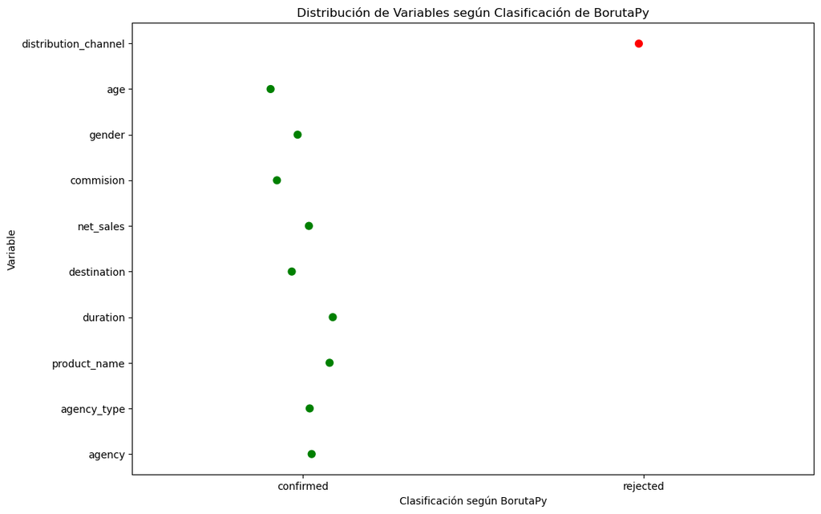

```python
# Obtenemos la clasificación de las variables según BorutaPy
classification = boruta_selector.support_

# Se crea un DataFrame con el nombre de las variables y su clasificación
classification_df = pd.DataFrame({"Variable": X_resampled.columns, "Classification": classification})

# Se mapea la clasificación a las categorías correctas
classification_df["Classification"] = classification_df["Classification"].map({True: "confirmed", False: "rejected"})

# Visualizamos un stripplot para las variables confirmadas y rechazadas
plt.figure(figsize=(12, 8))
sns.stripplot(x="Classification", y="Variable", data=classification_df, palette={"confirmed": "green", "rejected": "red"}, jitter=True, size=8)
plt.xlabel("Clasificación según BorutaPy")
plt.title("Distribución de Variables según Clasificación de BorutaPy")
plt.show()
```

Se observa que el algoritmo de Boruta ha rechazado la variable "distribution_channel" por no considerarla importante para la ejecución de los modelos de aprendizaje automático.

```python
# Aplicar las variables seleccionadas a los conjuntos de entrenamiento y test.
X_train_selected = X_resampled[accepted_features]
X_test_selected = X_test[accepted_features]

# Verificamos las dimensiones de los conjuntos que se utilizaran.
print("Dimensiones del conjunto de entrenamiento con variables seleccionadas:", X_train_selected.shape)
print("Dimensiones del conjunto de prueba con variables seleccionadas:", X_test_selected.shape)
```

```
Dimensiones del conjunto de entrenamiento con variables seleccionadas: (55649, 9)
Dimensiones del conjunto de prueba con variables seleccionadas: (17939, 9)
```

## 3. Creación de modelos de aprendizaje automático.

Primeramente, visualizamos las dimensiones de los subconjuntos de datos tras realizar el desbalanceo de clases y haber elegido las variables significativas para la realización de los modelos.

```python
# Dimensiones para todos los subconjuntos después del desbalanceo y selección de variables
print("\nDimensiones después del desbalanceo y selección de variables:")
print("X_train_selected:", X_train_selected.shape)
print("Y_resampled:", Y_resampled.shape)
print("X_test_selected:", X_test_selected.shape)
print("Y_test:", Y_test.shape)
```

```
Dimensiones después del desbalanceo y selección de variables:
X_train_selected: (55649, 9)
Y_resampled: (55649,)
X_test_selected: (17939, 9)
Y_test: (17939,)
```

Se procede a la realización de los diferentes modelos de aprendizaje automático. En primer lugar, se realizan los modelos de regresión logística y Naïve Bayes que pueden ser considerados como modelos más clásicos y posteriormente se realizan modelos más complejos como el árbol de decisión, Random Forest, Gradient Boosting, Extreme Gradient Boosting o k-NN vecinos.

### 3.1 Modelo de Regresión Logística.

```
Accuracy en el conjunto de prueba (Logistic Regression): 0.8433580467138636
Precision en el conjunto de prueba (Logistic Regression): 0.06226219301279834
Recall en el conjunto de prueba (Logistic Regression): 0.6451612903225806
Coeficiente de Kappa en el conjunto de prueba (Logistic Regression): 0.08768433146946175

Matriz confusión test
 [[14949  2711]
 [   99   180]]
```

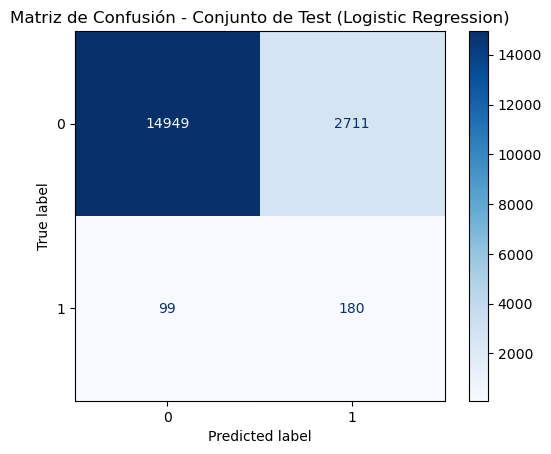

```python
# Creamos un clasificador de regresión logística
logistic_regression_classifier = LogisticRegression(random_state=0, max_iter = 1000)

# Entrenamos el modelo con el conjunto de entrenamiento
logistic_regression_classifier.fit(X_train_selected, Y_resampled)
# Se realiza la predicción sobre el conjunto de test y se calculan las principales métricas de accuracy, precision, recall y
# kappa.
y_pred_logistic = logistic_regression_classifier.predict(X_test_selected)
accuracy_logistic = accuracy_score(Y_test, y_pred_logistic)
precision_logistic = precision_score(Y_test, y_pred_logistic)
recall_logistic = recall_score(Y_test, y_pred_logistic)
kappa_logistic = cohen_kappa_score(Y_test, y_pred_logistic)

# Se muestran las métricas de rendimiento
print("Accuracy en el conjunto de prueba (Logistic Regression):", accuracy_logistic)
print("Precision en el conjunto de prueba (Logistic Regression):", precision_logistic)
print("Recall en el conjunto de prueba (Logistic Regression):", recall_logistic)
print("Coeficiente de Kappa en el conjunto de prueba (Logistic Regression):", kappa_logistic)

# Se visualiza la matriz de confusión para los datos de test.
conf_matrix_test_logistic = confusion_matrix(Y_test, y_pred_logistic)
print("\nMatriz confusión test\n", conf_matrix_test_logistic)
ConfusionMatrixDisplay.from_estimator(logistic_regression_classifier, X_test_selected, Y_test, cmap=plt.cm.Blues)
plt.title("Matriz de Confusión - Conjunto de Test (Logistic Regression)")
plt.show()
```

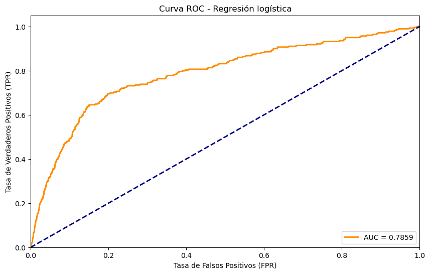

```python
# Obtenemos las probabilidades de las predicciones en el conjunto de test con las clases positivas
y_score_logistic = logistic_regression_classifier.predict_proba(X_test_selected)[:, 1]

# Calculamos la curva de ROC
fpr, tpr, _ = roc_curve(Y_test, y_score_logistic)
roc_auc = auc(fpr, tpr)

# Plot de la curva ROC
plt.figure(figsize=(10, 6))
plt.plot(fpr, tpr, color="darkorange", lw=2, label=f"AUC = {roc_auc:.4f}")
plt.plot([0, 1], [0, 1], color="navy", lw=2, linestyle="--")
plt.xlim([0.0, 1.0])
plt.ylim([0.0, 1.05])
plt.xlabel("Tasa de Falsos Positivos (FPR)")
plt.ylabel("Tasa de Verdaderos Positivos (TPR)")
plt.title("Curva ROC - Regresión logística")
plt.legend(loc="lower right")
plt.show()
```

### 3.2 Modelo de Naïve Bayes.

```
Accuracy en el conjunto de prueba (Naive Bayes): 0.836947432967278
Precision en el conjunto de prueba (Naive Bayes): 0.05958721704394141
Recall en el conjunto de prueba (Naive Bayes): 0.6415770609318996
Coeficiente de Kappa en el conjunto de prueba (Naive Bayes): 0.08294542028702567

Matriz confusión test
 [[14835  2825]
 [  100   179]]
```

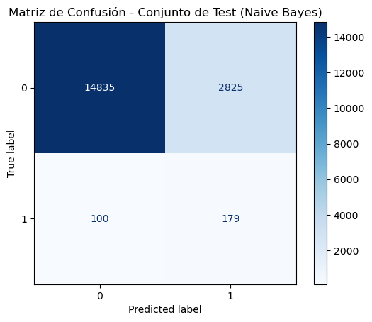

```python
# Creamos un clasificador Naive Bayes Gaussiano
naive_bayes_classifier = GaussianNB()

# Entrenamos el modelo con el conjunto de entrenamiento resampleado
naive_bayes_classifier.fit(X_train_selected, Y_resampled)

# Se realizan las predicciones en el conjunto de prueba
y_pred_naive_bayes = naive_bayes_classifier.predict(X_test_selected)

# Calculamos métricas de rendimiento del modelo
accuracy_naive_bayes = accuracy_score(Y_test, y_pred_naive_bayes)
precision_naive_bayes = precision_score(Y_test, y_pred_naive_bayes)
recall_naive_bayes = recall_score(Y_test, y_pred_naive_bayes)
kappa_naive_bayes = cohen_kappa_score(Y_test, y_pred_naive_bayes)

# Mostramos métricas de rendimiento del modelo
print("Accuracy en el conjunto de prueba (Naive Bayes):", accuracy_naive_bayes)
print("Precision en el conjunto de prueba (Naive Bayes):", precision_naive_bayes)
print("Recall en el conjunto de prueba (Naive Bayes):", recall_naive_bayes)
print("Coeficiente de Kappa en el conjunto de prueba (Naive Bayes):", kappa_naive_bayes)


# Se visualiza la matriz de confusión para los datos de test.
conf_matrix_naive_bayes = confusion_matrix(Y_test, y_pred_naive_bayes)
print("\nMatriz confusión test\n", conf_matrix_naive_bayes)
ConfusionMatrixDisplay.from_estimator(naive_bayes_classifier, X_test_selected, Y_test , cmap=plt.cm.Blues)
plt.title("Matriz de Confusión - Conjunto de Test (Naive Bayes)")
plt.show()
```

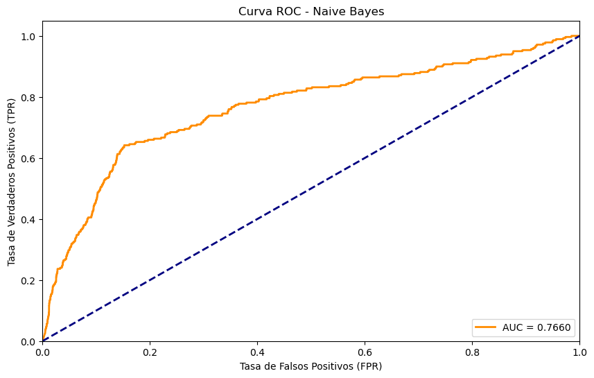

```python
# Obtenemos las probabilidades de las predicciones en el conjunto de test con las clases positivas
y_score_naive_bayes = naive_bayes_classifier.predict_proba(X_test_selected)[:, 1]

# Calculamos la curva ROC
fpr_nb, tpr_nb, _ = roc_curve(Y_test, y_score_naive_bayes)
roc_auc_nb = auc(fpr_nb, tpr_nb)

# Plot de la curva ROC
plt.figure(figsize=(10, 6))
plt.plot(fpr_nb, tpr_nb, color="darkorange", lw=2, label=f"AUC = {roc_auc_nb:.4f}")
plt.plot([0, 1], [0, 1], color="navy", lw=2, linestyle="--")
plt.xlim([0.0, 1.0])
plt.ylim([0.0, 1.05])
plt.xlabel("Tasa de Falsos Positivos (FPR)")
plt.ylabel("Tasa de Verdaderos Positivos (TPR)")
plt.title("Curva ROC - Naive Bayes")
plt.legend(loc="lower right")
plt.show()
```

### 3.3 Modelo árbol de decisión (DecissionTree).

```
Accuracy en el conjunto de prueba (Decission tree): 0.9476002006800825
Precision en el conjunto de prueba (Decission tree): 0.06225165562913907
Recall en el conjunto de prueba (Decission tree): 0.16845878136200718
Coeficiente de Kappa en el conjunto de prueba (Decission tree): 0.06978163065498444

Matriz confusión test
 [[16952   708]
 [  232    47]]
```

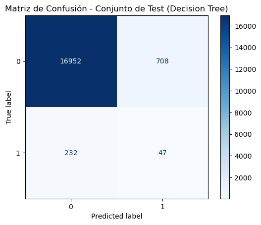

```python
# Creamos un clasificador de árbol de decisión
decision_tree_classifier = DecisionTreeClassifier(random_state=0)

# Entrenamos el modelo con el conjunto de entrenamiento
decision_tree_classifier.fit(X_train_selected, Y_resampled)

# Se realizan las predicciones en el conjunto de prueba
y_pred_decision_tree = decision_tree_classifier.predict(X_test_selected)

# Calculamos métricas de rendimiento del modelo
accuracy_decision_tree = accuracy_score(Y_test, y_pred_decision_tree)
precision_decision_tree = precision_score(Y_test, y_pred_decision_tree)
recall_decision_tree = recall_score(Y_test, y_pred_decision_tree)
kappa_decision_tree = cohen_kappa_score(Y_test, y_pred_decision_tree)

# Mostramos métricas de rendimiento del modelo
print("Accuracy en el conjunto de prueba (Decission tree):", accuracy_decision_tree)
print("Precision en el conjunto de prueba (Decission tree):", precision_decision_tree)
print("Recall en el conjunto de prueba (Decission tree):", recall_decision_tree)
print("Coeficiente de Kappa en el conjunto de prueba (Decission tree):", kappa_decision_tree)


# Visualizamos la matriz de confusión
conf_matrix_decision_tree = confusion_matrix(Y_test, y_pred_decision_tree)
print("\nMatriz confusión test\n", conf_matrix_decision_tree)
ConfusionMatrixDisplay.from_estimator(decision_tree_classifier, X_test_selected, Y_test, cmap=plt.cm.Blues)
plt.title("Matriz de Confusión - Conjunto de Test (Decision Tree)")
plt.show()
```

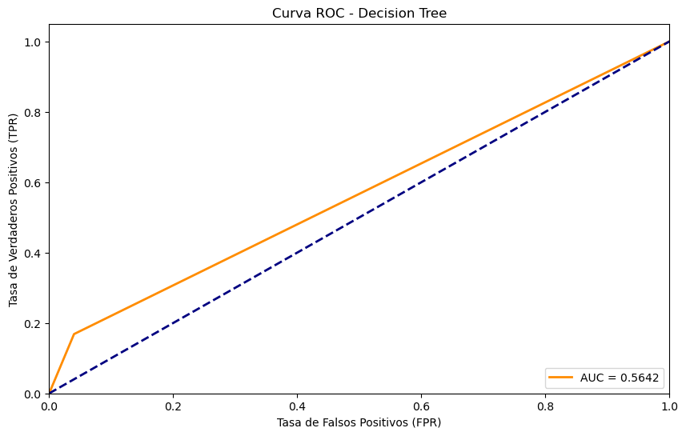

```python
# Obtenemos las probabilidades de las predicciones en el conjunto de test con las clases positivas
y_score_decission_tree = decision_tree_classifier.predict_proba(X_test_selected)[:, 1]
# Calculamos la curva ROC
fpr, tpr, _ = roc_curve(Y_test, y_pred_decision_tree)
roc_auc = auc(fpr, tpr)

# Plot de la curva ROC
plt.figure(figsize=(10, 6))
plt.plot(fpr, tpr, color="darkorange", lw=2, label=f"AUC = {roc_auc:.4f}")
plt.plot([0, 1], [0, 1], color="navy", lw=2, linestyle="--")
plt.xlim([0.0, 1.0])
plt.ylim([0.0, 1.05])
plt.xlabel("Tasa de Falsos Positivos (FPR)")
plt.ylabel("Tasa de Verdaderos Positivos (TPR)")
plt.title("Curva ROC - Decision Tree")
plt.legend(loc="lower right")
plt.show()
```

### 3.4. Modelo árbol aleatorio de clasificación (RandomforestClassifier).

```
Accuracy en el conjunto de prueba (Random Forest): 0.9554601705780701
Precision en el conjunto de prueba (Random Forest): 0.07095709570957096
Recall en el conjunto de prueba (Random Forest): 0.15412186379928317
Coeficiente de Kappa en el conjunto de prueba (Random Forest): 0.07752711488648989

Matriz confusión test
 [[17097   563]
 [  236    43]]
```

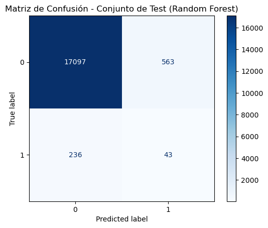

```python
# Creamos el modelo y se entrena el conjunto de entrenamiento.
clf = RandomForestClassifier(random_state=0)
clf.fit(X_train_selected, Y_resampled)

# Se realiza la predicción sobre el conjunto de test y se calculan las principales métricas de accuracy, precision, recall y
# el coeficient de kappa.
y_pred_clf = clf.predict(X_test_selected)
accuracy_clf = accuracy_score(Y_test, y_pred_clf)
precision_clf = precision_score(Y_test, y_pred_clf)
recall_clf = recall_score(Y_test, y_pred_clf)
kappa_clf = cohen_kappa_score(Y_test, y_pred_clf)

# Se muestran las  métricas de rendimiento
print("Accuracy en el conjunto de prueba (Random Forest):", accuracy_clf)
print("Precision en el conjunto de prueba (Random Forest):", precision_clf)
print("Recall en el conjunto de prueba (Random Forest):", recall_clf)
print("Coeficiente de Kappa en el conjunto de prueba (Random Forest):", kappa_clf)


# Se visualiza la matriz de confusión para los datos de test.
conf_matrix_test_clf = confusion_matrix(Y_test, y_pred_clf)
print("\nMatriz confusión test\n", conf_matrix_test_clf)
ConfusionMatrixDisplay.from_estimator(clf, X_test_selected, Y_test, cmap=plt.cm.Blues)
plt.title("Matriz de Confusión - Conjunto de Test (Random Forest)")
plt.show()
```

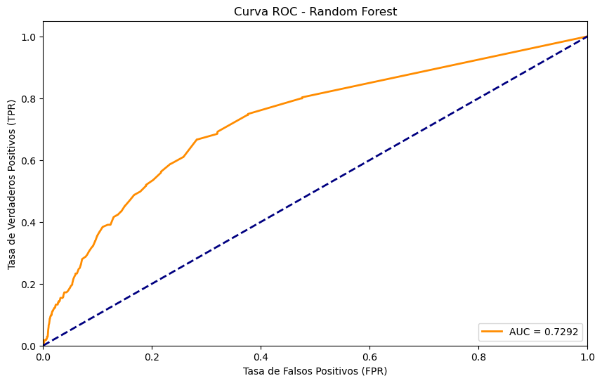

```python
# Obtenemos las probabilidades de las predicciones en el conjunto de test con las clases positivas
y_score_clf = clf.predict_proba(X_test_selected)[:, 1]
# Calculamos la curva ROC
fpr, tpr, _ = roc_curve(Y_test, y_score_clf)
roc_auc = auc(fpr, tpr)

# Plot de la curva ROC
plt.figure(figsize=(10, 6))
plt.plot(fpr, tpr, color="darkorange", lw=2, label=f"AUC = {roc_auc:.4f}")
plt.plot([0, 1], [0, 1], color="navy", lw=2, linestyle="--")
plt.xlim([0.0, 1.0])
plt.ylim([0.0, 1.05])
plt.xlabel("Tasa de Falsos Positivos (FPR)")
plt.ylabel("Tasa de Verdaderos Positivos (TPR)")
plt.title("Curva ROC - Random Forest")
plt.legend(loc="lower right")
plt.show()
```

### 3.5. Modelo Gradient Boosting.

```
Accuracy en el conjunto de prueba (Gradient Boosting): 0.8876191537989855
Precision en el conjunto de prueba (Gradient Boosting): 0.07279881947860305
Recall en el conjunto de prueba (Gradient Boosting): 0.5304659498207885
Coeficiente de Kappa en el conjunto de prueba (Gradient Boosting): 0.1035070068695636

Matriz confusión test
 [[15775  1885]
 [  131   148]]
```

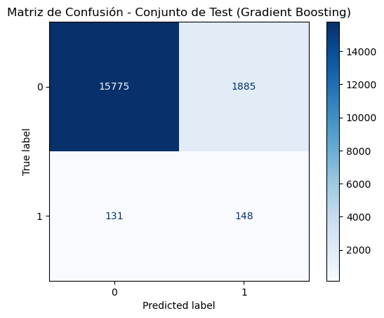

```python
# Creamos un clasificador Gradient Boosting
gradient_boosting_classifier = GradientBoostingClassifier(random_state=0)

# Entrenamos el modelo con el conjunto de entrenamiento resampleado
gradient_boosting_classifier.fit(X_train_selected, Y_resampled)

# Se realizan las predicciones en el conjunto de prueba
y_pred_gradient_boosting = gradient_boosting_classifier.predict(X_test_selected)

# Calculamos métricas de rendimiento del modelo
accuracy_gradient_boosting = accuracy_score(Y_test, y_pred_gradient_boosting)
precision_gradient_boosting = precision_score(Y_test, y_pred_gradient_boosting)
recall_gradient_boosting = recall_score(Y_test, y_pred_gradient_boosting)
kappa_gradient_boosting = cohen_kappa_score(Y_test, y_pred_gradient_boosting)

# Mostramos métricas de rendimiento del modelo
print("Accuracy en el conjunto de prueba (Gradient Boosting):", accuracy_gradient_boosting)
print("Precision en el conjunto de prueba (Gradient Boosting):", precision_gradient_boosting)
print("Recall en el conjunto de prueba (Gradient Boosting):", recall_gradient_boosting)
print("Coeficiente de Kappa en el conjunto de prueba (Gradient Boosting):", kappa_gradient_boosting)

# Calculamos la matriz de confusión
conf_matrix_gradient_boosting = confusion_matrix(Y_test, y_pred_gradient_boosting)

# Se visualiza la matriz de confusión para los datos de test.
conf_matrix_test_gradient_boosting = confusion_matrix(Y_test, y_pred_gradient_boosting)
print("\nMatriz confusión test\n", conf_matrix_test_gradient_boosting)
ConfusionMatrixDisplay.from_estimator(gradient_boosting_classifier, X_test_selected, Y_test, cmap=plt.cm.Blues)
plt.title("Matriz de Confusión - Conjunto de Test (Gradient Boosting)")
plt.show()
```

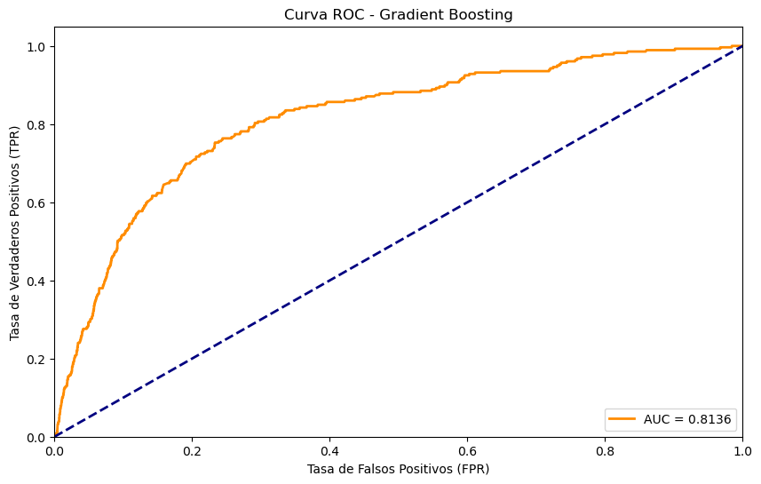

```python
# Obtenemos las probabilidades de las predicciones en el conjunto de test con las clases positivas
y_score_gb = gradient_boosting_classifier.predict_proba(X_test_selected)[:, 1]
# Calculamos la curva ROC
fpr, tpr, _ = roc_curve(Y_test, y_score_gb)
roc_auc = auc(fpr, tpr)

# Plot de la curva ROC
plt.figure(figsize=(10, 6))
plt.plot(fpr, tpr, color="darkorange", lw=2, label=f"AUC = {roc_auc:.4f}")
plt.plot([0, 1], [0, 1], color="navy", lw=2, linestyle="--")
plt.xlim([0.0, 1.0])
plt.ylim([0.0, 1.05])
plt.xlabel("Tasa de Falsos Positivos (FPR)")
plt.ylabel("Tasa de Verdaderos Positivos (TPR)")
plt.title("Curva ROC - Gradient Boosting")
plt.legend(loc="lower right")
plt.show()
```

### 3.6. Modelo Extreme Gradient Boosting.

```
Accuracy en el conjunto de prueba (XGBoost): 0.9392385305758404
Precision en el conjunto de prueba (XGBoost): 0.06631016042780749
Recall en el conjunto de prueba (XGBoost): 0.2222222222222222
Coeficiente de Kappa en el conjunto de prueba (XGBoost): 0.08010390936938172

Matriz confusión test
 [[16787   873]
 [  217    62]]
```

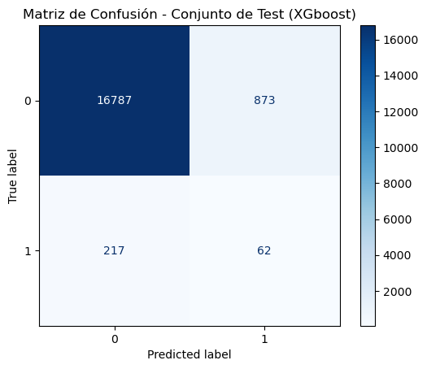

```python
# Creamos un clasificador XGBoost
xgboost_classifier = xgb.XGBClassifier(random_state=0)

# Entrenamos el modelo con el conjunto de entrenamiento resampleado
xgboost_classifier.fit(X_train_selected, Y_resampled)

# Se realizan las predicciones en el conjunto de prueba
y_pred_xgboost = xgboost_classifier.predict(X_test_selected)

# Calculamos métricas de rendimiento del modelo
accuracy_xgboost = accuracy_score(Y_test, y_pred_xgboost)
precision_xgboost = precision_score(Y_test, y_pred_xgboost)
recall_xgboost = recall_score(Y_test, y_pred_xgboost)
kappa_xgboost = cohen_kappa_score(Y_test, y_pred_xgboost)

# Mostramos métricas de rendimiento del modelo
print("Accuracy en el conjunto de prueba (XGBoost):", accuracy_xgboost)
print("Precision en el conjunto de prueba (XGBoost):", precision_xgboost)
print("Recall en el conjunto de prueba (XGBoost):", recall_xgboost)
print("Coeficiente de Kappa en el conjunto de prueba (XGBoost):", kappa_xgboost)

# Se visualiza la matriz de confusión para los datos de test.
conf_matrix_test_xgboosting = confusion_matrix(Y_test, y_pred_xgboost)
print("\nMatriz confusión test\n", conf_matrix_test_xgboosting)
ConfusionMatrixDisplay.from_estimator(xgboost_classifier, X_test_selected, Y_test, cmap=plt.cm.Blues)
plt.title("Matriz de Confusión - Conjunto de Test (XGboost)")
plt.show()
```

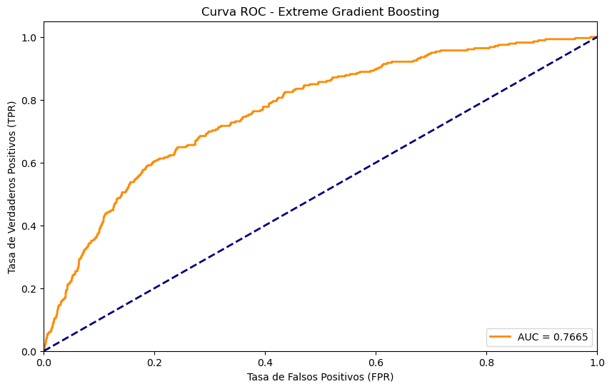

```python
# Obtenemos las probabilidades de las predicciones en el conjunto de test con las clases positivas
y_score_xgb = xgboost_classifier.predict_proba(X_test_selected)[:, 1]
# Calculamos la curva ROC
fpr, tpr, _ = roc_curve(Y_test, y_score_xgb)
roc_auc = auc(fpr, tpr)

# Plot de la curva ROC
plt.figure(figsize=(10, 6))
plt.plot(fpr, tpr, color="darkorange", lw=2, label=f"AUC = {roc_auc:.4f}")
plt.plot([0, 1], [0, 1], color="navy", lw=2, linestyle="--")
plt.xlim([0.0, 1.0])
plt.ylim([0.0, 1.05])
plt.xlabel("Tasa de Falsos Positivos (FPR)")
plt.ylabel("Tasa de Verdaderos Positivos (TPR)")
plt.title("Curva ROC - Extreme Gradient Boosting")
plt.legend(loc="lower right")
plt.show()
```

### 3.7. Modelo kNN vecinos.

```
Accuracy en el conjunto de prueba (k-NN): 0.8742962260995596
Precision en el conjunto de prueba (k-NN): 0.04595588235294118
Recall en el conjunto de prueba (k-NN): 0.35842293906810035
Coeficiente de Kappa en el conjunto de prueba (k-NN): 0.05542404028651993

Matriz confusión test
 [[15584  2076]
 [  179   100]]
```

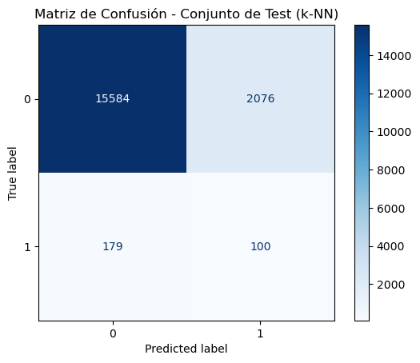

```python
# Creamos un clasificador k-NN
knn_classifier = KNeighborsClassifier()

# Entrenamos el modelo con el conjunto de entrenamiento resampleado
knn_classifier.fit(X_train_selected, Y_resampled)

# Se realizan las predicciones en el conjunto de prueba
y_pred_knn = knn_classifier.predict(X_test_selected)

# Calculamos métricas de rendimiento del modelo
accuracy_knn = accuracy_score(Y_test, y_pred_knn)
precision_knn = precision_score(Y_test, y_pred_knn)
recall_knn = recall_score(Y_test, y_pred_knn)
kappa_knn = cohen_kappa_score(Y_test, y_pred_knn)

# Mostramos métricas de rendimiento del modelo
print("Accuracy en el conjunto de prueba (k-NN):", accuracy_knn)
print("Precision en el conjunto de prueba (k-NN):", precision_knn)
print("Recall en el conjunto de prueba (k-NN):", recall_knn)
print("Coeficiente de Kappa en el conjunto de prueba (k-NN):", kappa_knn)

# Calculamos la matriz de confusión
conf_matrix_knn = confusion_matrix(Y_test, y_pred_knn)

# Se visualiza la matriz de confusión para los datos de test.
conf_matrix_test_knn = confusion_matrix(Y_test, y_pred_knn)
print("\nMatriz confusión test\n", conf_matrix_test_knn)
ConfusionMatrixDisplay.from_estimator(knn_classifier, X_test_selected, Y_test, cmap=plt.cm.Blues)
plt.title("Matriz de Confusión - Conjunto de Test (k-NN)")
plt.show()
```

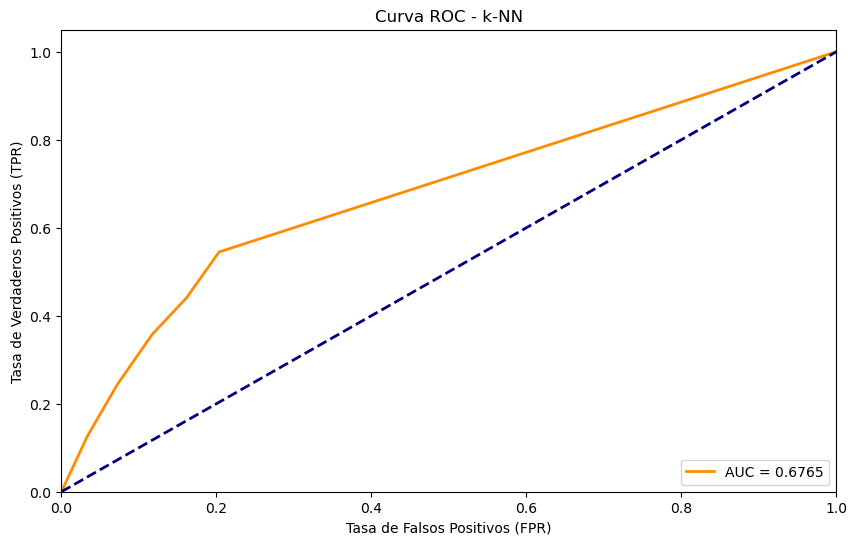

```python
# Obtenemos las probabilidades de las predicciones en el conjunto de test con las clases positivas
y_score_knn = knn_classifier.predict_proba(X_test_selected)[:, 1]
# Calculamos la curva ROC
fpr, tpr, _ = roc_curve(Y_test, y_score_knn)
roc_auc = auc(fpr, tpr)

# Plot de la curva ROC
plt.figure(figsize=(10, 6))
plt.plot(fpr, tpr, color="darkorange", lw=2, label=f"AUC = {roc_auc:.4f}")
plt.plot([0, 1], [0, 1], color="navy", lw=2, linestyle="--")
plt.xlim([0.0, 1.0])
plt.ylim([0.0, 1.05])
plt.xlabel("Tasa de Falsos Positivos (FPR)")
plt.ylabel("Tasa de Verdaderos Positivos (TPR)")
plt.title("Curva ROC - k-NN")
plt.legend(loc="lower right")
plt.show()
```

## 5. Bibliografía.

- Material UOC: Estadística Avanzada: Preprocesado de datos.
- Material UOC: Modelos avanzados de minería de datos: PEC1, PEC2, PEC3 (Modelos No supervisados y Modelos Supervisados).
- https://www.kaggle.com/datasets/mhdzahier/travel-insurance/code
- https://www.kaggle.com/code/residentmario/automated-feature-selection-with-boruta
- https://www.kaggle.com/code/ahmettezcantekin/getting-started-with-boruta
- https://www.kaggle.com/code/kiranvairagade/ordinal-encoder
- https://scikit-learn.org/stable/
- https://towardsdatascience.com/the-search-for-categorical-correlation-a1cf7f1888c9
- https://www.kaggle.com/ayangupta/predict-the-claim
- https://www.kaggle.com/code/prashant111/logistic-regression-classifier-tutorial
- https://www.kaggle.com/code/prashant111/knn-classifier-tutorial
- https://www.kaggle.com/code/dansbecker/xgboost#Example